# Plot ERP amplitudes

Luna Li | luna.0x4c@gmail.com

**Last updated: 2026-11-05**

# load ERP data

```r
#dir = "/Volumes/toshiba/eeg_data_backup/10_erp_mean"
dir = "/Users/lunarneko/Desktop/10_erp_mean"

erp_list = list.files(path=paste0(dir),pattern="*.csv",full.names = TRUE)

erp = NULL

for (i in 1:3) {
  filename = erp_list[i]

  erp[[i]] = read.csv(erp_list[i])

  if (str_detect(filename,"teststim")) {
    names(erp)[i] = "stim"        # `is_old`
  } else if (str_detect(filename,"resp")) {
    names(erp)[i] = "resp"        # `is_correct`
  } else if (str_detect(filename,"feed")) {
    names(erp)[i] = "feed"        # `trial_is_fpf`
  } else {stop("Check file names")}

  # make sure no subj missing
  if (n_distinct(erp[[i]]$sub) != 58) {
    stop("Check N")
  }

  # make sure no cue group missing
  if (any(is.na(erp[[i]]$cue_flip))) {
    stop("Check cue_flip")
  }

}

x1 = c("feed","resp","stim")
x2 = names(erp)
if (!identical(x1,x2)) {
  stop("Check df names in `erp`")
} else {
  message("Success! df names match, ok to proceed")
}

valid_eeg_sub = data.frame(sub = unique(erp[[1]]$sub)) %>% mutate(has_eeg = TRUE)
nrow(valid_eeg_sub)   # valid n=58
```

```
## [1] 58
```

```r
# n per cue group: 0=true, 1=reversed
erp[[1]] %>% distinct(sub, cue_flip) %>% count(cue_flip)  # n=25 true, n=33 rev
```

| cue_flip | n |
| --- | --- |
| 0 | 25 |
| 1 | 33 |

# erp components info

```r
erp_info = tribble(
  ~erp_name, ~df_type, ~roi,                ~erp_win,
  "FN400",   "stim",   c("Fz","FCz","Cz"),  c(300,500),
  "LPC",     "stim",   c("P3","P4"),        c(600,800),
  #"LPN",     "stim",   c("Pz","P3","P4"),   c(900,1100),
  #"pre-resp","resp",   c("FCz"),            c(-200,0),
  "ERN",     "resp",   c("Cz","FCz"),       c(0,150),
  "FRN",     "feed",   c("Cz","FCz"),       c(250,375),
  "P3",      "feed",   c("Pz","CPz"),       c(400,500)
)

min_n = 3

source("plot_erp.R")
source("plot_diff.R")
```

# plot erpwave/erpamp by batch

**DEFAULT: grouped down to `resptype`; can combine cells later**

```r
i=0
save=F
all_amps_list <- mean_amps_list <- NULL
erpwave_list <- erpamp_list <- diffwave_list <- diffamp_list <- list()

for (i in 1:nrow(erp_info)) {

  df_type = erp_info$df_type[i]
  print(df_type)
  roi = erp_info$roi[i][[1]]
  erp_win = erp_info$erp_win[i][[1]]  # make sure this is numeric

  curr_erp = erp_info$erp_name[i]
  print(curr_erp)

  df = erp[[df_type]]

  if (df_type=="feed") {
    df = df %>% filter(task!="strategic")  # text not formatted yet
  }

  # full epoch, subj x cell timepoint -> grand average erpwave
  all_amp_all_cells  = prep_erp_cells(df=df, df_type=df_type, chanlist=roi, erp_win=NULL,    avg=FALSE, save=save)
  # erp window mean, subj x cell      -> grand average erpamp by cell
  mean_amp_all_cells = prep_erp_cells(df=df, df_type=df_type, chanlist=roi, erp_win=erp_win, avg=TRUE,  save=save)
  # keep these in case collapsing across cells for diffwave/diffamp

  # drop sparse cells
  # use these for resptype model/fig
  all_amp_valid_cells  = all_amp_all_cells  %>% filter(cell_ntrials >= min_n)
  mean_amp_valid_cells = mean_amp_all_cells %>% filter(cell_ntrials >= min_n)

  # tag df with additional info
  all_amps_list[[i]]  <- all_amp_all_cells
  mean_amps_list[[i]] <- mean_amp_all_cells
  names(all_amps_list)[i] = curr_erp
  names(mean_amps_list)[i] = curr_erp

  # erpwave
  erpwave_df  = prep_erp_wave(all_amp_valid_cells)
  erpwave_list[[i]] <- plot_erp_wave(erpwave_df, erp_win=erp_win, export_option="no legend", save=save)
  erpwave_fig = erpwave_list[[i]]

  # erpamp - descriptive fig with weighted mean/SE
  erpamp_df  = prep_erp_amp(mean_amp_valid_cells)
  erpamp_list[[i]] <- plot_erp_amp(erpamp_df, erp_win=erp_win, layout="panel", export_option="no legend", save=save)
  erpamp_fig = erpamp_list[[i]]

  # save name for figs
  names(erpwave_list)[i] = curr_erp
  names(erpamp_list)[i]  = curr_erp

  # export legend separately, once per epoch type
  # stim/resp should be identical; feed should have 6 resptype instead of 4
  if (curr_erp %in% c("FN400","ERN","FRN")) {
    plot_erp_wave(erpwave_df, erp_win=erp_win, export_option="legend only", save=save)
    # add 1in padding for feed amp
    if (df_type=="feed") {width=4} else (width=NULL)
    plot_erp_amp(erpamp_df, erp_win=erp_win, layout="column", export_option="legend only", save=save,width=width)
  }

  # erpamp - lmer-based amp ~ taskcond x resptype contrasts
  #erpamp_lmer = test_amp_lmer(mean_amp_valid_cells, save=save)  # ignore rank dificient warning from empty cells

}
```

```
## [1] "stim"
## [1] "FN400"
## [1] "stim"
## [1] "LPC"
## [1] "resp"
## [1] "ERN"
## [1] "feed"
## [1] "FRN"
## [1] "feed"
## [1] "P3"
```

```r
names(all_amps_list)
```

```
## [1] "FN400" "LPC"   "ERN"   "FRN"   "P3"
```

```r
names(mean_amps_list)
```

```
## [1] "FN400" "LPC"   "ERN"   "FRN"   "P3"
```

```r
names(erpwave_list)
```

```
## [1] "FN400" "LPC"   "ERN"   "FRN"   "P3"
```

```r
names(erpamp_list)
```

```
## [1] "FN400" "LPC"   "ERN"   "FRN"   "P3"
```

## recode

```r
# is_correct
# is_criterr
# is_old
# say_old
# is_fpf

# HARD CODED batch recoding for all dfs
recode_levels = function(df) {

  df_type = unique(df$df_type)

  newdf = df %>%
    mutate(
      # incorrect - correct
      is_correct = case_when(resptype %in% c("Hit","CR")  ~ "Correct",
                             resptype %in% c("FA","Miss") ~ "Incorrect",
                             .default = NA),
      # congruent vs opposite error to bias manipulation; baseline are neutral errors
      is_criterr = case_when(cond=="Lib" & resptype=="FA"    ~ "Congruent",
                             cond=="Con" & resptype=="Miss"  ~ "Congruent",
                             cond=="Lib" & resptype=="Miss"  ~ "Incongruent",
                             cond=="Con" & resptype=="FA"    ~ "Incongruent",
                             cond=="Neutral" & resptype %in% c("FA","Miss") ~ "Neutral",
                             resptype %in% c("Hit","CR") ~ "Correct",
                             .default = NA),
      # item status
      is_old = case_when(resptype %in% c("Hit","Miss") ~ "Old",
                         resptype %in% c("FA","CR")    ~ "New",
                         .default = NA),
      # response
      say_old = case_when(resptype %in% c("Hit","FA")  ~ "Old",
                          resptype %in% c("CR","Miss") ~ "New",
                          .default = NA)
    )

  if (df_type=="feed") {
    newdf = newdf %>%
      filter(task0!="Strategic") %>%
      mutate(
        # feedback type
        is_fpf = case_when(resptype_6 %in% c("Hit","CR") ~ "Correct (real)",
                           resptype_6 %in% c("FA (real)","Miss (real)") ~ "Incorrect",
                           resptype_6 %in% c("FA (FPF)","Miss (FPF)") ~ "Correct (FPF)",
                           .default=NA))
  }

  return(newdf)
}
```

```r
# collapse cell means - use as needed for specified variables
collapse_levels = function(df, vars=NULL,type=c("wave","amp"), contrast_var, cell_weight=TRUE) {

  if (is.null(vars)) {
    # enter custom list as needed (e.g. if collapsing across cond)
    vars = c("sub","cue_flip","cue","task0","task","cond","taskcond","time_ms",
             "df_type","erp_win","erp_chans")
    if (type=="amp") {
      vars = vars[vars!="time_ms"]
    }
  }

  # LONG format of contrast levels
  newdf = df %>% group_by(across(all_of(c(vars,contrast_var)))) %>%
    summarise(mean_amp_unwt = mean(mean_amp, na.rm=TRUE),
              mean_amp_wt   = weighted.mean(mean_amp, cell_ntrials),
              cell_ntrials = sum(cell_ntrials),
              .groups="drop")
  # sparse cells will be removed in `prep_diff_wave/amp`

  if (isFALSE(cell_weight)) {
    # requires a `mean_amp` column for next step
    # unweighted = averaging over subcells
    newdf$mean_amp = newdf$mean_amp_unwt
  } else if (isTRUE(cell_weight)) {
    # weighted by subcell ntrials
    newdf$mean_amp = newdf$mean_amp_wt
  } else (stop("Enter TRUE/FALSE for `cell_weight`"))

  return(newdf)   # should be sub x taskcond x `contrast_var` x `time_ms`
  # [!!!] MAY NEED ADDITIONAL FILTERING, e.g. if incorrect-correct contrast limited to non-FPF trials
  # this then goes into `prep_diff_wave/amp`

}
```

```r
erpwave_df_list <- erpamp_df_list <- NULL

for (i in 1:length(all_amps_list)) {
  erpwave_df_list[[i]] = recode_levels(all_amps_list[[i]])
  names(erpwave_df_list)[i] = names(all_amps_list)[i]
}

for (i in 1:length(mean_amps_list)) {
  erpamp_df_list[[i]] = recode_levels(mean_amps_list[[i]])
  names(erpamp_df_list)[i] = names(mean_amps_list)[i]
}
```

```r
get_cell_n = function(df, vars) {
  cell_n = df %>% group_by(across(all_of(vars))) %>%
    filter(cell_ntrials >= min_n) %>%
    summarise(ntrials_mean = mean(cell_ntrials),
              ntrials_sd   = sd(cell_ntrials),
              ntrials_min  = min(cell_ntrials),
              ntrials_max  = max(cell_ntrials),
              nsub_valid   = sum(cell_ntrials >= min_n),
              .groups = "drop")
  return(cell_n)
}

get_cell_n(erpamp_df_list$FN400, vars = c("task","cond", "resptype"))
```

| task | cond | resptype | ntrials_mean | ntrials_sd | ntrials_min | ntrials_max | nsub_valid |
| --- | --- | --- | --- | --- | --- | --- | --- |
| Baseline | Neutral | Hit | 62.258621 | 11.914256 | 35 | 86 | 58 |
| Baseline | Neutral | FA | 25.362069 | 9.788461 | 7 | 47 | 58 |
| Baseline | Neutral | CR | 72.706897 | 10.981657 | 47 | 93 | 58 |
| Baseline | Neutral | Miss | 36.293103 | 11.424825 | 11 | 61 | 58 |
| FPF | Con | Hit | 33.086207 | 8.037815 | 16 | 48 | 58 |
| FPF | Con | FA | 14.875000 | 5.457480 | 4 | 27 | 56 |
| FPF | Con | CR | 35.068966 | 6.169711 | 22 | 48 | 58 |
| FPF | Con | Miss | 16.473684 | 7.442890 | 4 | 31 | 57 |
| FPF | Lib | Hit | 34.137931 | 7.535759 | 15 | 46 | 58 |
| FPF | Lib | FA | 15.620690 | 6.899854 | 4 | 40 | 58 |

[output cut: 18 more lines]

```r
get_cell_n(erpamp_df_list$ERN,   vars = c("task","cond", "resptype"))
```

| task | cond | resptype | ntrials_mean | ntrials_sd | ntrials_min | ntrials_max | nsub_valid |
| --- | --- | --- | --- | --- | --- | --- | --- |
| Baseline | Neutral | Hit | 62.241379 | 11.913887 | 35 | 86 | 58 |
| Baseline | Neutral | FA | 25.379310 | 9.806599 | 7 | 47 | 58 |
| Baseline | Neutral | CR | 72.775862 | 10.887049 | 47 | 93 | 58 |
| Baseline | Neutral | Miss | 36.275862 | 11.456697 | 11 | 61 | 58 |
| FPF | Con | Hit | 33.155172 | 8.012713 | 16 | 48 | 58 |
| FPF | Con | FA | 14.892857 | 5.446195 | 4 | 27 | 56 |
| FPF | Con | CR | 35.086207 | 6.159530 | 22 | 48 | 58 |
| FPF | Con | Miss | 16.508772 | 7.445331 | 4 | 31 | 57 |
| FPF | Lib | Hit | 34.224138 | 7.576610 | 15 | 46 | 58 |
| FPF | Lib | FA | 15.637931 | 6.922372 | 4 | 40 | 58 |

[output cut: 18 more lines]

```r
get_cell_n(erpamp_df_list$FRN,   vars = c("task","cond", "resptype_6"))  # no strategic
```

| task | cond | resptype_6 | ntrials_mean | ntrials_sd | ntrials_min | ntrials_max | nsub_valid |
| --- | --- | --- | --- | --- | --- | --- | --- |
| Baseline | Neutral | Hit | 61.724138 | 11.834818 | 33 | 86 | 58 |
| Baseline | Neutral | FA (real) | 25.086207 | 9.767983 | 6 | 46 | 58 |
| Baseline | Neutral | CR | 71.965517 | 10.758865 | 47 | 92 | 58 |
| Baseline | Neutral | Miss (real) | 35.896552 | 11.322528 | 11 | 61 | 58 |
| FPF | Con | Hit | 32.896552 | 8.005896 | 16 | 47 | 58 |
| FPF | Con | FA (real) | 14.750000 | 5.428042 | 4 | 27 | 56 |
| FPF | Con | CR | 34.620690 | 6.095231 | 22 | 48 | 58 |
| FPF | Con | Miss (real) | 4.863636 | 1.706225 | 3 | 9 | 44 |
| FPF | Con | Miss (FPF) | 12.500000 | 6.102161 | 3 | 24 | 56 |
| FPF | Lib | Hit | 33.896552 | 7.498982 | 15 | 45 | 58 |

[output cut: 4 more lines]

# define contrasts

```r
# informational only, contrast does not pull from this list due to repeated rows
contrast_info = tribble(
  # contrast levels should be listed in the
  ~row, ~erp_name, ~df_type, ~roi,                ~erp_win,    ~contrast_var,  ~contrast_levels,

  # stim
  1,    "FN400",   "stim",   c("Fz","FCz","Cz"),  c(300,500),  "resptype",     c("Hit","CR"),
  2,    "FN400",   "stim",   c("Fz","FCz","Cz"),  c(300,500),  "is_old",       c("Old","New"),
  3,    "LPC",     "stim",   c("P3","P4"),        c(600,800),  "resptype",     c("Hit","CR"),

  # resp
  4,    "ERN",     "resp",   c("Cz","FCz"),       c(0,150),    "is_correct",   c("Incorrect","Correct"),
  5,    "ERN",     "resp",   c("Cz","FCz"),       c(0,150),    "say_old",      c("Old","New"),

  # feed
  6,    "FRN",     "feed",   c("Cz","FCz"),       c(250,375),  "is_correct",   c("Incorrect","Correct"),
  7,    "FRN",     "feed",   c("Cz","FCz"),       c(250,375),  "is_fpf",       c("Correct (FPF)","Correct (real)"),
  8,    "FRN",     "feed",   c("Cz","FCz"),       c(250,375),  "is_fpf",       c("Correct (FPF)","Incorrect"),
  9,    "P3",      "feed",   c("Pz","CPz"),       c(400,500),  "is_correct",   c("Incorrect","Correct"),
  10,   "P3",      "feed",   c("Pz","CPz"),       c(400,500),  "is_fpf",       c("Correct (FPF)","Correct (real)"),
  11,   "P3",      "feed",   c("Pz","CPz"),       c(400,500),  "is_fpf",       c("Correct (FPF)","Incorrect")
)
```

```r
# BEFORE PLOTTING, filter out trials where `contrast_levels` values cover more than intended cells
# e.g. `resptype` probably does not need filtering; `is_correct` needs filtering when limiting to only FPF trials

plot_custom_diff = function(erpwave_in, erpamp_in, curr_erpname, curr_title,
                            contrast_var, contrast_levels, save_fig=F) {

  curr_win = erp_info$erp_win[erp_info$erp_name==curr_erpname][[1]]  # for full epoch wave window shading only

  diffwave_df1 = collapse_levels(erpwave_in, contrast_var=contrast_var, type="wave")   # long format of contrast levels
  diffwave_df2 = prep_erp_diffwave(diffwave_df1,contrast_var=contrast_var,contrast_levels=contrast_levels, avg=TRUE)  # grand average & wide format
  print(
    plot_erp_diffwave(diffwave_df2, erp_win = curr_win, contrast_title = curr_title, save=save_fig)
  )

  diffamp_df1 = collapse_levels(erpamp_in, contrast_var=contrast_var, type="amp")
  diffamp_df2 = prep_erp_diffamp(diffamp_df1, contrast_var=contrast_var,contrast_levels=contrast_levels, avg=TRUE)
  print(
    plot_erp_diffamp(diffamp_df2, contrast_title = curr_title, save=save_fig)
  )

}
```

**SPECIFIC CONTRASTS BELOW**

```r
# get cohen's d
get_eff = function(model, model_contrast, type=c("within","between"), method=NULL, by=NULL) {
  # model object, contrast object, pairs list (optional)
  # within = within block (e.g. hit-cr within each taskcond; simple effects, interactions, single contrasts)
  # between = cross block (e.g. compare hit-cr effects across taskcond)
  sigma = sqrt(sum(as.data.frame(VarCorr(model))$vcov))   # standardizer for d [aka total SD]
  edf = df.residual(model)

  type = match.arg(type)
  if (type == "between") {
    model_contrast = contrast(model_contrast, by=by, method=method)  # inherit `by`
  }
  eff = eff_size(model_contrast, sigma=sigma, edf=edf, method="identity")

  return(eff)
}
```

```r
get_des = function(df, vars, save=save_des, folder=NULL) {
  # df should be model df
  # produces raw cell M/SD averaged across subjects - will NOT be the same as model emmeans
  descriptives = df %>%
    group_by(across(all_of(vars))) %>%
    summarise(mean = mean(mean_amp, na.rm=TRUE),
              sd   = sd(mean_amp, na.rm=TRUE),
              nsub = n(),
              .groups = "drop")

  if (isTRUE(save)) {
    if (is.null(folder)) {
      folder = "/Users/lunarneko/Desktop/11_erp_stats/"
    }
    # e.g. des_stim_FzFCzCz_300_500_task_cond_resptype.csv
    filename = paste0(folder, "des_", unique(df$df_type), "_",
                      str_remove_all(unique(df$erp_chans), " "), "_",
                      str_replace_all(unique(df$erp_win), " ", "_"), "_",
                      paste(vars, collapse="_"), ".csv")

    write.csv(descriptives, filename, row.names=FALSE)
  }

  return(descriptives)
}
```

```r
# group differences on ~taskcond*cue grid [same as `cue_list` in behavioral `get_sdt.Rmd`]
# taskcond varies fastest: 5 true then 5 rev cells
cue_list = list("strategic con-lib true-rev" = c(0,0,0,1,-1,  0,0,0,-1,1),
                "con strategic true-rev"     = c(0,0,0,1,0,   0,0,0,-1,0),
                "lib strategic true-rev"     = c(0,0,0,0,1,   0,0,0,0,-1),
                # base/FPF for reference only / consistency check
                "FPF con-lib true-rev"       = c(0,1,-1,0,0,  0,-1,1,0,0),
                "baseline true-rev"          = c(1,0,0,0,0,  -1,0,0,0,0))
```

# FEED

## real correct vs real incorrect, without FPF

- erp: FRN, P3
- subset: FPF & baseline task, minus FPF trials
- collapse: correct/incorrect
- diffwave: incorrect-correct x task

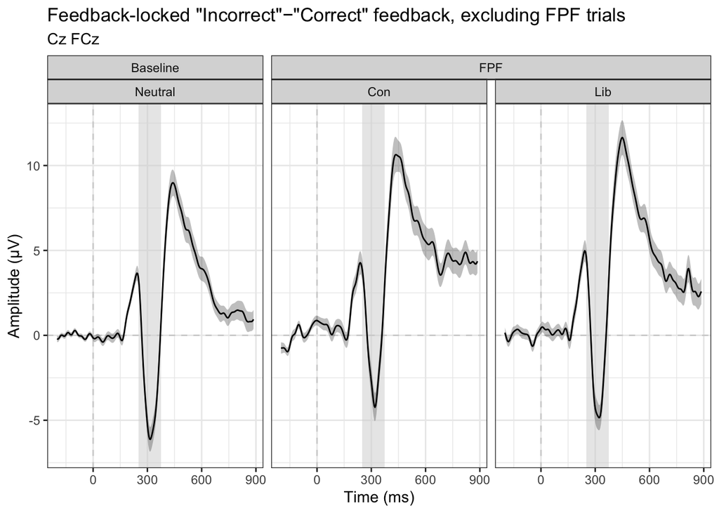

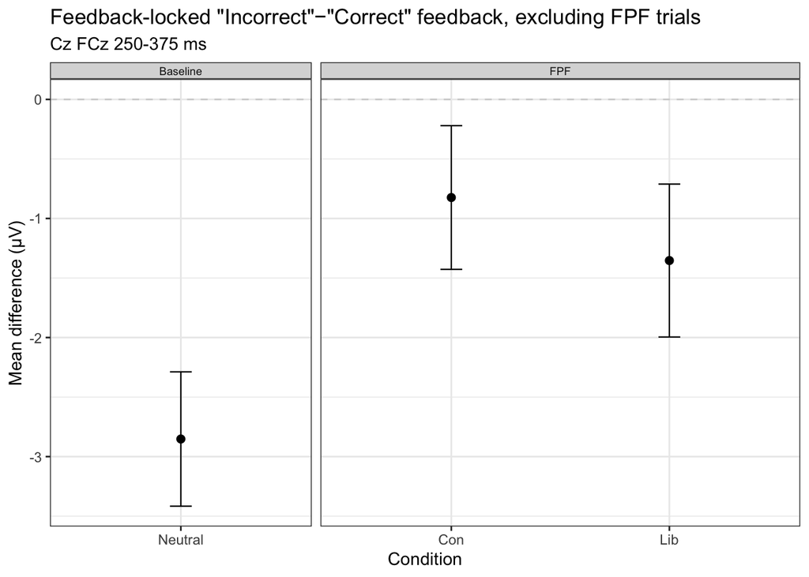

```r
# FRN
erpwave_in = erpwave_df_list$FRN %>% filter(task=="Baseline" | (task=="FPF" & trial_is_fpf==0))
erpamp_in  = erpamp_df_list$FRN  %>% filter(task=="Baseline" | (task=="FPF" & trial_is_fpf==0))

# ==== plot diff ===============================================================
plot_custom_diff(erpwave_in, erpamp_in,
                 curr_erpname = "FRN",
                 curr_title = glue::glue("\"Incorrect\"{minus}\"Correct\" feedback, excluding FPF trials"),
                 contrast_var = "is_correct", contrast_levels = c("Incorrect","Correct"), save_fig=save_fig)
```

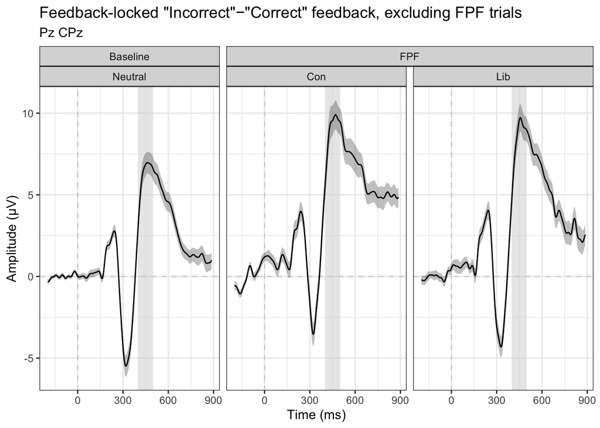

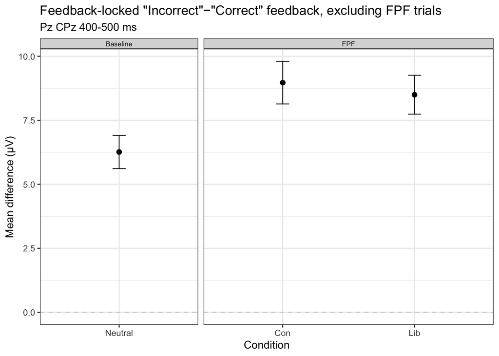

```r
# P3
erpwave_in = erpwave_df_list$P3 %>% filter(task=="Baseline" | (task=="FPF" & trial_is_fpf==0))
erpamp_in  = erpamp_df_list$P3  %>% filter(task=="Baseline" | (task=="FPF" & trial_is_fpf==0))

# ==== plot diff ===============================================================
plot_custom_diff(erpwave_in, erpamp_in,
                 curr_erpname = "P3",
                 curr_title = glue::glue("\"Incorrect\"{minus}\"Correct\" feedback, excluding FPF trials"),
                 contrast_var = "is_correct", contrast_levels = c("Incorrect","Correct"), save_fig=save_fig)
```

## FPF vs real correct, matched by resp old/new

- erp: FRN, P3
- subset: FPF only, lib = FA FPF - hit; con = miss FPF - CR
- collapse: is_fpf
- diffwave/diffamp: FPF-cprrect
- model: amp ~ cond * is_fpf
- contrasts: lib FPF-correct; con FPF-correct; interaction [lib diff vs con diff]

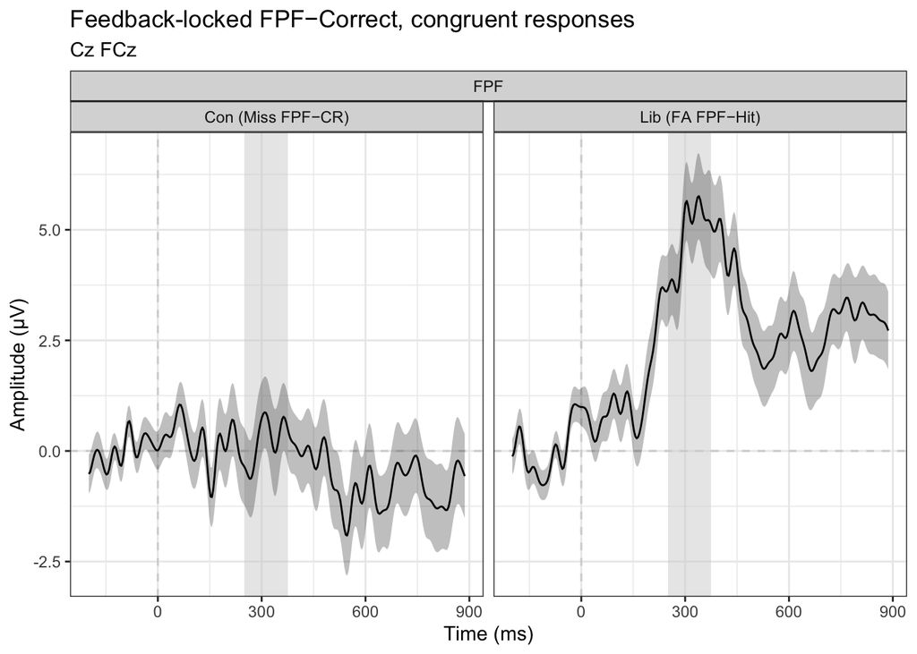

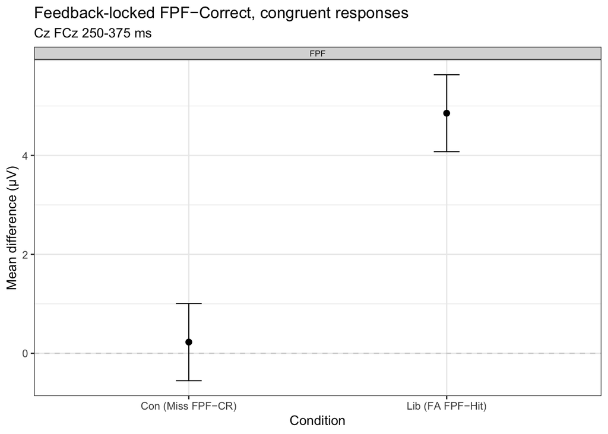

```r
# FRN
erpwave_in = erpwave_df_list$FRN %>% filter(task=="FPF") %>%
  filter((cond=="Lib" & resptype_6 %in% c("Hit","FA (FPF)")) |
           (cond=="Con" & resptype_6 %in% c("CR","Miss (FPF)"))) %>%
  mutate(cond = case_when(cond=="Lib" ~ glue("Lib (FA FPF{minus}Hit)"),
                          cond=="Con" ~ glue("Con (Miss FPF{minus}CR)"),
                          .default = NA))

erpamp_in  = erpamp_df_list$FRN  %>% filter(task=="FPF") %>%
  filter((cond=="Lib" & resptype_6 %in% c("Hit","FA (FPF)")) |
           (cond=="Con" & resptype_6 %in% c("CR","Miss (FPF)"))) %>%
  mutate(cond = case_when(cond=="Lib" ~ glue("Lib (FA FPF{minus}Hit)"),
                          cond=="Con" ~ glue("Con (Miss FPF{minus}CR)"),
                          .default = NA))

# ==== plot diff ===============================================================
plot_custom_diff(erpwave_in, erpamp_in,
                 curr_erpname = "FRN",
                 curr_title = glue("FPF{minus}Correct, congruent responses"),
                 contrast_var = "is_fpf", contrast_levels = c("Correct (FPF)","Correct (real)"), save_fig=save_fig)
```

```r
# ==== model: cond x is_fpf ====================================================
diffamp_model_df = collapse_levels(erpamp_in, contrast_var="is_fpf", type="amp") %>%
  filter(cell_ntrials >= min_n)

# raw descriptives for model data [NOT model emmeans]
get_des(diffamp_model_df, vars = c("taskcond", "is_fpf"))
```

| taskcond | is_fpf | mean | sd | nsub |
| --- | --- | --- | --- | --- |
| FPF Con | Correct (FPF) | 8.071944 | 7.111835 | 56 |
| FPF Con | Correct (real) | 8.032793 | 6.123299 | 58 |
| FPF Lib | Correct (FPF) | 11.686121 | 8.108927 | 58 |
| FPF Lib | Correct (real) | 6.831574 | 5.106491 | 58 |

```r
model.lm = lmer(mean_amp ~ cond * is_fpf + (1|sub) + (1|sub:cond) + (1|sub:is_fpf), data=diffamp_model_df)
model.emm   = emmeans(model.lm, ~ is_fpf | cond, lmer.df = "satterthwaite")
model.pairs = pairs(model.emm)

model.emm; model.pairs
```

```
## cond = Con (Miss FPF−CR):
##  is_fpf         emmean    SE  df lower.CL upper.CL
##  Correct (FPF)    8.07 0.886 106     6.32     9.83
##  Correct (real)   8.03 0.878 103     6.29     9.77
##
## cond = Lib (FA FPF−Hit):
##  is_fpf         emmean    SE  df lower.CL upper.CL
##  Correct (FPF)   11.69 0.878 103     9.94    13.43
##  Correct (real)   6.83 0.878 103     5.09     8.57
##
## Degrees-of-freedom method: satterthwaite
## Confidence level used: 0.95
```

```
## cond = Con (Miss FPF−CR):
##  contrast                       estimate    SE  df t.ratio p.value
##  Correct (FPF) - Correct (real)   0.0406 0.781 136   0.052  0.9587
##
## cond = Lib (FA FPF−Hit):
##  contrast                       estimate    SE  df t.ratio p.value
##  Correct (FPF) - Correct (real)   4.8545 0.772 135   6.284 <0.0001
##
## Degrees-of-freedom method: satterthwaite
```

```r
get_eff(model = model.lm, model_contrast = model.pairs, type="within")
```

```
## cond = Con (Miss FPF−CR):
##  contrast                         effect.size    SE  df lower.CL upper.CL
##  (Correct (FPF) - Correct (real))     0.00606 0.117 136   -0.225    0.237
##
## cond = Lib (FA FPF−Hit):
##  contrast                         effect.size    SE  df lower.CL upper.CL
##  (Correct (FPF) - Correct (real))     0.72567 0.121 135    0.487    0.964
##
## sigma used for effect sizes: 6.69
## Degrees-of-freedom method: inherited from satterthwaite when re-gridding
## Confidence level used: 0.95
```

```r
summary(model.pairs, by=NULL, adjust="holm", infer=c(T,T))
```

|  | contrast | cond | estimate | SE | df | lower.CL | upper.CL | t.ratio | p.value |
| --- | --- | --- | --- | --- | --- | --- | --- | --- | --- |
| 1 | Correct (FPF) - Correct (real) | Con (Miss FPF−CR) | 0.04055084 | 0.7806942 | 136.4115 | -1.728824 | 1.809926 | 0.05194203 | 9.586509e-01 |
| 2 | Correct (FPF) - Correct (real) | Lib (FA FPF−Hit) | 4.85454673 | 0.7724954 | 134.8013 | 3.103520 | 6.605573 | 6.28424015 | 8.482207e-09 |

```r
contrast_out = contrast(emmeans(model.lm, ~ is_fpf * cond, lmer.df = "satterthwaite"),
                          adjust="holm", interaction="pairwise", infer=c(T,T)) -> FRN_isfpf_cond   # need this for later
contrast_out
```

```
##  is_fpf_pairwise                cond_pairwise                        estimate
##  Correct (FPF) - Correct (real) Con (Miss FPF−CR) - Lib (FA FPF−Hit)    -4.81
##    SE  df lower.CL upper.CL t.ratio p.value
##  1.02 114    -6.83     -2.8  -4.738 <0.0001
##
## Degrees-of-freedom method: satterthwaite
## Confidence level used: 0.95
```

```r
get_eff(model = model.lm, model_contrast = contrast_out, type="within")
```

```
##  contrast
##  (Correct (FPF) - Correct (real) Con (Miss FPF−CR) - Lib (FA FPF−Hit))
##  effect.size    SE  df lower.CL upper.CL
##        -0.72 0.156 114    -1.03   -0.411
##
## sigma used for effect sizes: 6.69
## Degrees-of-freedom method: inherited from satterthwaite when re-gridding
## Confidence level used: 0.95
```

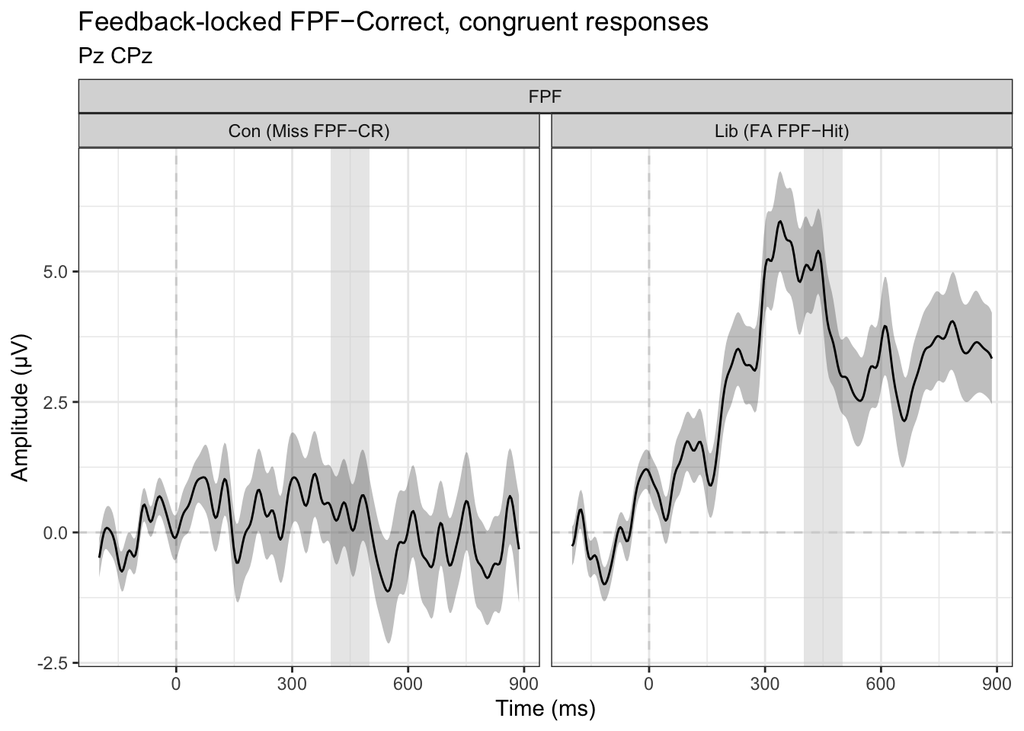

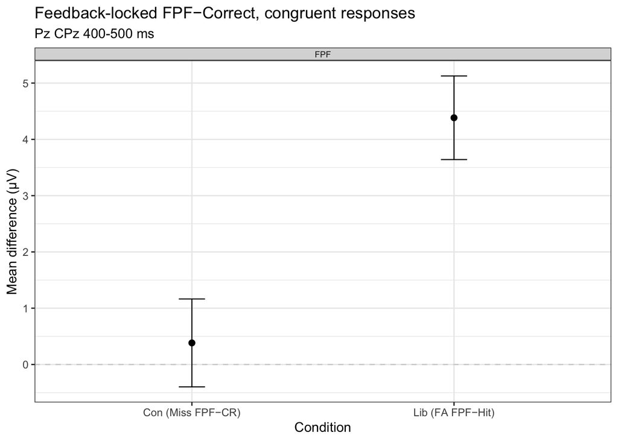

```r
# P3
erpwave_in = erpwave_df_list$P3 %>% filter(task=="FPF") %>%
  filter((cond=="Lib" & resptype_6 %in% c("Hit","FA (FPF)")) |
           (cond=="Con" & resptype_6 %in% c("CR","Miss (FPF)"))) %>%
  mutate(cond = case_when(cond=="Lib" ~ glue("Lib (FA FPF{minus}Hit)"),
                          cond=="Con" ~ glue("Con (Miss FPF{minus}CR)"),
                          .default = NA))

erpamp_in  = erpamp_df_list$P3  %>% filter(task=="FPF") %>%
  filter((cond=="Lib" & resptype_6 %in% c("Hit","FA (FPF)")) |
           (cond=="Con" & resptype_6 %in% c("CR","Miss (FPF)"))) %>%
  mutate(cond = case_when(cond=="Lib" ~ glue("Lib (FA FPF{minus}Hit)"),
                          cond=="Con" ~ glue("Con (Miss FPF{minus}CR)"),
                          .default = NA))

# ==== plot diff ===============================================================
plot_custom_diff(erpwave_in, erpamp_in,
                 curr_erpname = "P3",
                 curr_title = glue("FPF{minus}Correct, congruent responses"),
                 contrast_var = "is_fpf", contrast_levels = c("Correct (FPF)","Correct (real)"), save_fig=save_fig)
```

```r
# ==== model: cond x is_fpf ====================================================
diffamp_model_df = collapse_levels(erpamp_in, contrast_var="is_fpf", type="amp") %>%
  filter(cell_ntrials >= min_n)

get_des(diffamp_model_df, vars = c("taskcond", "is_fpf"))
```

| taskcond | is_fpf | mean | sd | nsub |
| --- | --- | --- | --- | --- |
| FPF Con | Correct (FPF) | 5.898796 | 7.560448 | 56 |
| FPF Con | Correct (real) | 5.551768 | 6.106249 | 58 |
| FPF Lib | Correct (FPF) | 7.819801 | 7.823582 | 58 |
| FPF Lib | Correct (real) | 3.436005 | 5.419285 | 58 |

```r
model.lm = lmer(mean_amp ~ cond * is_fpf + (1|sub) + (1|sub:cond) + (1|sub:is_fpf), data=diffamp_model_df)
model.emm   = emmeans(model.lm, ~ is_fpf | cond, lmer.df = "satterthwaite")
model.pairs = pairs(model.emm)

model.emm; model.pairs
```

```
## cond = Con (Miss FPF−CR):
##  is_fpf         emmean    SE  df lower.CL upper.CL
##  Correct (FPF)    5.76 0.900 104     3.97     7.54
##  Correct (real)   5.55 0.893 101     3.78     7.32
##
## cond = Lib (FA FPF−Hit):
##  is_fpf         emmean    SE  df lower.CL upper.CL
##  Correct (FPF)    7.82 0.893 101     6.05     9.59
##  Correct (real)   3.44 0.893 101     1.66     5.21
##
## Degrees-of-freedom method: satterthwaite
## Confidence level used: 0.95
```

```
## cond = Con (Miss FPF−CR):
##  contrast                       estimate    SE  df t.ratio p.value
##  Correct (FPF) - Correct (real)    0.203 0.767 112   0.265  0.7914
##
## cond = Lib (FA FPF−Hit):
##  contrast                       estimate    SE  df t.ratio p.value
##  Correct (FPF) - Correct (real)    4.384 0.758 110   5.780 <0.0001
##
## Degrees-of-freedom method: satterthwaite
```

```r
get_eff(model = model.lm, model_contrast = model.pairs, type="within")
```

```
## cond = Con (Miss FPF−CR):
##  contrast                         effect.size    SE  df lower.CL upper.CL
##  (Correct (FPF) - Correct (real))      0.0299 0.113 112   -0.194    0.253
##
## cond = Lib (FA FPF−Hit):
##  contrast                         effect.size    SE  df lower.CL upper.CL
##  (Correct (FPF) - Correct (real))      0.6446 0.116 110    0.415    0.874
##
## sigma used for effect sizes: 6.801
## Degrees-of-freedom method: inherited from satterthwaite when re-gridding
## Confidence level used: 0.95
```

```r
summary(model.pairs, by=NULL, adjust="holm", infer=c(T,T))
```

|  | contrast | cond | estimate | SE | df | lower.CL | upper.CL | t.ratio | p.value |
| --- | --- | --- | --- | --- | --- | --- | --- | --- | --- |
| 1 | Correct (FPF) - Correct (real) | Con (Miss FPF−CR) | 0.2033486 | 0.7668896 | 112.0001 | -1.538975 | 1.945672 | 0.2651602 | 7.913734e-01 |
| 2 | Correct (FPF) - Correct (real) | Lib (FA FPF−Hit) | 4.3837964 | 0.7583769 | 110.1183 | 2.660412 | 6.107180 | 5.7804982 | 1.408695e-07 |

```r
contrast_out = contrast(emmeans(model.lm, ~ is_fpf * cond, lmer.df = "satterthwaite"),
                         adjust="holm", infer=c(T,T), interaction="pairwise") -> P3_isfpf_cond   # need this for later
contrast_out
```

```
##  is_fpf_pairwise                cond_pairwise                        estimate
##  Correct (FPF) - Correct (real) Con (Miss FPF−CR) - Lib (FA FPF−Hit)    -4.18
##    SE   df lower.CL upper.CL t.ratio p.value
##  1.03 56.5    -6.25    -2.12  -4.055  0.0002
##
## Degrees-of-freedom method: satterthwaite
## Confidence level used: 0.95
```

```r
get_eff(model = model.lm, model_contrast = contrast_out, type="within")
```

```
##  contrast
##  (Correct (FPF) - Correct (real) Con (Miss FPF−CR) - Lib (FA FPF−Hit))
##  effect.size    SE   df lower.CL upper.CL
##       -0.615 0.154 56.5   -0.924   -0.306
##
## sigma used for effect sizes: 6.801
## Degrees-of-freedom method: inherited from satterthwaite when re-gridding
## Confidence level used: 0.95
```

## control analysis, baseline only

- subset: baseline only
- model: amp ~ resptype [hit-cr; fa-miss]

```r
# FRN
erpamp_in = erpamp_df_list$FRN  %>% filter(task=="Baseline") %>% filter(cell_ntrials >= min_n)
levels(erpamp_df_list$FRN$resptype)   # in this order: hit,fa,cr,miss
```

```
## [1] "Hit"  "FA"   "CR"   "Miss"
```

```r
get_des(erpamp_in, vars = c("resptype"))
```

| resptype | mean | sd | nsub |
| --- | --- | --- | --- |
| Hit | 8.760978 | 5.777134 | 58 |
| FA | 6.919230 | 6.289291 | 58 |
| CR | 10.187613 | 5.542228 | 58 |
| Miss | 6.558581 | 6.212516 | 58 |

```r
# ==== model: resptype =========================================================
model.lm = lmer(mean_amp ~ resptype + (1|sub), data=erpamp_in)
model.emm   = emmeans(model.lm, ~ resptype, lmer.df = "satterthwaite")
model.pairs = pairs(model.emm)
model.emm; model.pairs
```

```
##  resptype emmean    SE   df lower.CL upper.CL
##  Hit        8.76 0.783 83.3     7.20    10.32
##  FA         6.92 0.783 83.3     5.36     8.48
##  CR        10.19 0.783 83.3     8.63    11.74
##  Miss       6.56 0.783 83.3     5.00     8.12
##
## Degrees-of-freedom method: satterthwaite
## Confidence level used: 0.95
```

```
##  contrast   estimate    SE  df t.ratio p.value
##  Hit - FA      1.842 0.541 171   3.402  0.0046
##  Hit - CR     -1.427 0.541 171  -2.635  0.0450
##  Hit - Miss    2.202 0.541 171   4.068  0.0004
##  FA - CR      -3.268 0.541 171  -6.037 <0.0001
##  FA - Miss     0.361 0.541 171   0.666  0.9097
##  CR - Miss     3.629 0.541 171   6.703 <0.0001
##
## Degrees-of-freedom method: satterthwaite
## P value adjustment: tukey method for comparing a family of 4 estimates
```

```r
# ===== contrasts ==============================================================
new_old_list = c(-0.5, 0.5, 0.5, -0.5)  # 0.5*(fa + cr) - 0.5*(hit + miss) [this is avg over fa - hit + cr - miss]
resptype_contrast = contrast(model.emm, list(new_old = new_old_list))
summary(resptype_contrast, by=NULL, adjust="holm", infer=c(TRUE, TRUE))
```

|  | contrast | estimate | SE | df | lower.CL | upper.CL | t.ratio | p.value |
| --- | --- | --- | --- | --- | --- | --- | --- | --- |
| 1 | new_old | 0.8936419 | 0.3828143 | 171 | 0.1379918 | 1.649292 | 2.334401 | 0.02073683 |

```r
get_eff(model.lm, model_contrast=resptype_contrast, type="within")
```

```
##  contrast effect.size     SE  df lower.CL upper.CL
##  new_old         0.15 0.0646 171   0.0224    0.277
##
## sigma used for effect sizes: 5.963
## Degrees-of-freedom method: inherited from satterthwaite when re-gridding
## Confidence level used: 0.95
```

```r
# ===== compare with `is_fpf` effect ===========================================
eff1 = summary(FRN_isfpf_cond, infer=c(T,T))
eff0 = summary(resptype_contrast, infer=c(T,T))

compare_isfpf_FRN = tibble(erp = "FRN",
                   eff1_lib_con = -eff1$estimate,   # output was con-lib, needs to flip sign here
                   eff0_item  = eff0$estimate,
                   eff0_lower = eff0$lower.CL,
                   eff0_upper = eff0$upper.CL,
                   corrected  = -eff1$estimate - 2*eff0$estimate,
                   worst_case = -eff1$estimate - 2*eff0$upper.CL)
compare_isfpf_FRN
```

| erp | eff1_lib_con | eff0_item | eff0_lower | eff0_upper | corrected | worst_case |
| --- | --- | --- | --- | --- | --- | --- |
| FRN | 4.813996 | 0.8936419 | 0.1379918 | 1.649292 | 3.026712 | 1.515412 |

```r
# P3
erpamp_in  = erpamp_df_list$P3  %>% filter(task=="Baseline") %>% filter(cell_ntrials >= min_n)
get_des(erpamp_in, vars = c("resptype"))
```

| resptype | mean | sd | nsub |
| --- | --- | --- | --- |
| Hit | 6.385783 | 6.162607 | 58 |
| FA | 13.847464 | 8.477170 | 58 |
| CR | 8.391592 | 6.460584 | 58 |
| Miss | 13.680133 | 7.781071 | 58 |

```r
# ==== model: resptype =========================================================
model.lm = lmer(mean_amp ~ resptype + (1|sub), data=erpamp_in)
model.emm   = emmeans(model.lm, ~ resptype, lmer.df = "satterthwaite")
model.pairs = pairs(model.emm)
model.emm; model.pairs
```

```
##  resptype emmean    SE   df lower.CL upper.CL
##  Hit        6.39 0.956 83.8     4.48     8.29
##  FA        13.85 0.956 83.8    11.95    15.75
##  CR         8.39 0.956 83.8     6.49    10.29
##  Miss      13.68 0.956 83.8    11.78    15.58
##
## Degrees-of-freedom method: satterthwaite
## Confidence level used: 0.95
```

```
##  contrast   estimate    SE  df t.ratio p.value
##  Hit - FA     -7.462 0.666 171 -11.204 <0.0001
##  Hit - CR     -2.006 0.666 171  -3.012  0.0157
##  Hit - Miss   -7.294 0.666 171 -10.953 <0.0001
##  FA - CR       5.456 0.666 171   8.192 <0.0001
##  FA - Miss     0.167 0.666 171   0.251  0.9944
##  CR - Miss    -5.289 0.666 171  -7.941 <0.0001
##
## Degrees-of-freedom method: satterthwaite
## P value adjustment: tukey method for comparing a family of 4 estimates
```

```r
# ===== contrasts ==============================================================
new_old_list = c(-0.5, 0.5, 0.5, -0.5)  # 0.5*(fa + cr) - 0.5*(hit + miss) [this is avg over fa - hit + cr - miss]
resptype_contrast = contrast(model.emm, list(new_old = new_old_list))
summary(resptype_contrast, by=NULL, adjust="holm", infer=c(TRUE, TRUE))
```

|  | contrast | estimate | SE | df | lower.CL | upper.CL | t.ratio | p.value |
| --- | --- | --- | --- | --- | --- | --- | --- | --- |
| 1 | new_old | 1.08657 | 0.4709103 | 171 | 0.157024 | 2.016116 | 2.307382 | 0.02223191 |

```r
get_eff(model.lm, model_contrast=resptype_contrast, type="within")
```

```
##  contrast effect.size    SE  df lower.CL upper.CL
##  new_old        0.149 0.065 171   0.0208    0.278
##
## sigma used for effect sizes: 7.282
## Degrees-of-freedom method: inherited from satterthwaite when re-gridding
## Confidence level used: 0.95
```

```r
# ===== compare with `is_fpf` effect ===========================================
eff1 = summary(P3_isfpf_cond, infer=c(T,T))
eff0 = summary(resptype_contrast, infer=c(T,T))

compare_isfpf_P3 = tibble(erp = "P3",
                  eff1_lib_con = -eff1$estimate,   # output was con-lib, needs to flip sign here
                  eff0_item  = eff0$estimate,
                  eff0_lower = eff0$lower.CL,
                  eff0_upper = eff0$upper.CL,
                  corrected  = -eff1$estimate - 2*eff0$estimate,
                  worst_case = -eff1$estimate - 2*eff0$upper.CL)
compare_isfpf_P3
```

| erp | eff1_lib_con | eff0_item | eff0_lower | eff0_upper | corrected | worst_case |
| --- | --- | --- | --- | --- | --- | --- |
| P3 | 4.180448 | 1.08657 | 0.157024 | 2.016116 | 2.007308 | 0.1482161 |

## manipulation check, FPF critical errors

- subset: FPF only, lib = FA FPF - FA real; con = miss FPF - miss real
- collapse: is_fpf
- model: amp ~ is_fpf, avg across lib/con
- diffwave/diffamp: FPF - not, collapsed across lib/con  
  skip for now

# STIM

### old/new memory effect, hit-CR

- ERP: FN400, LPC
- subset: hit/CR only
- model: amp ~ taskcond x resptype[hit/cr]
- contrast: ??
- erpwave/erpamp: full taskcond x resptype
- diffwave/diffamp: hit-CR x taskcond

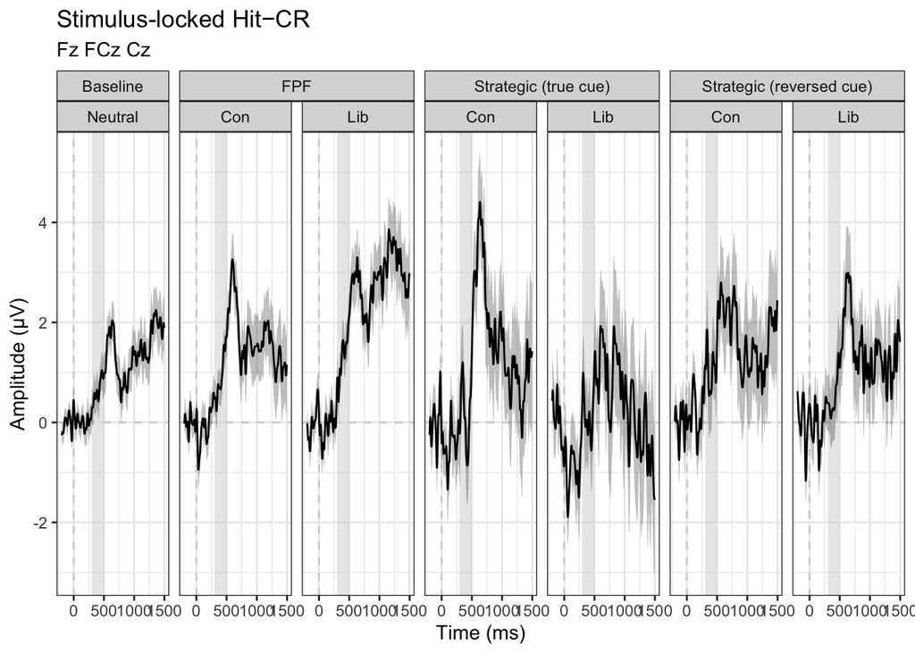

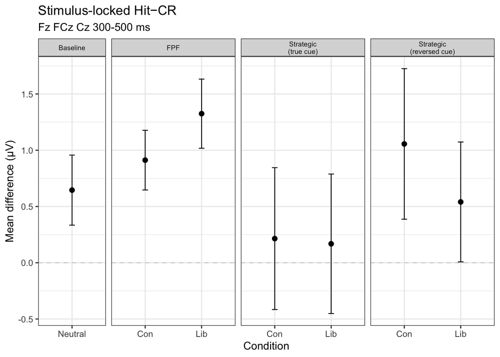

```r
# FN400
erpwave_in = erpwave_df_list$FN400
erpamp_in  = erpamp_df_list$FN400

# ==== plot diff ===============================================================
plot_custom_diff(erpwave_in, erpamp_in,
                 curr_erpname = "FN400",
                 curr_title = glue("Hit{minus}CR"),
                 contrast_var = "resptype", contrast_levels = c("Hit","CR"), save_fig=save_fig)
```

```r
# ==== model: taskcond x hitcr =================================================
diffamp_model_df = collapse_levels(erpamp_in, contrast_var="resptype", type="amp") %>%
  filter(cell_ntrials >= min_n) %>%
  filter(resptype %in% c("Hit","CR"))

get_des(diffamp_model_df, vars = c("task","cond","resptype"))
```

| task | cond | resptype | mean | sd | nsub |
| --- | --- | --- | --- | --- | --- |
| Baseline | Neutral | Hit | -11.69773 | 5.451818 | 58 |
| Baseline | Neutral | CR | -12.34344 | 5.286818 | 58 |
| FPF | Con | Hit | -11.39611 | 5.625358 | 58 |
| FPF | Con | CR | -12.30819 | 5.286543 | 58 |
| FPF | Lib | Hit | -11.35482 | 5.369034 | 58 |
| FPF | Lib | CR | -12.67995 | 5.440791 | 58 |
| Strategic (true cue) | Con | Hit | -11.35683 | 5.559302 | 25 |
| Strategic (true cue) | Con | CR | -11.57155 | 4.941047 | 25 |
| Strategic (true cue) | Lib | Hit | -11.31408 | 5.399856 | 25 |
| Strategic (true cue) | Lib | CR | -11.48272 | 5.536827 | 25 |

[output cut: 4 more lines]

```r
model.lm = lmer(mean_amp ~ taskcond * resptype * cue + (1|sub) + (1|sub:taskcond) + (1|sub:resptype), data=diffamp_model_df)
model.emm   = emmeans(model.lm, ~ resptype | taskcond*cue, lmer.df = "satterthwaite")
model.pairs = pairs(model.emm)

model.emm; model.pairs
```

```
## taskcond = Baseline Neutral, cue = True:
##  resptype emmean   SE   df lower.CL upper.CL
##  Hit       -11.9 1.09 81.3    -14.0    -9.71
##  CR        -12.7 1.09 81.3    -14.9   -10.56
##
## taskcond = FPF Con, cue = True:
##  resptype emmean   SE   df lower.CL upper.CL
##  Hit       -12.0 1.09 81.3    -14.2    -9.83
##  CR        -12.6 1.09 81.3    -14.8   -10.43
##
## taskcond = FPF Lib, cue = True:
##  resptype emmean   SE   df lower.CL upper.CL
##  Hit       -12.0 1.09 81.3    -14.1    -9.80
##  CR        -13.3 1.09 81.3    -15.5   -11.12
##
## taskcond = Strategic Con, cue = True:
##  resptype emmean   SE   df lower.CL upper.CL
##  Hit       -11.4 1.09 81.3    -13.5    -9.19
##  CR        -11.6 1.09 81.3    -13.7    -9.40
##
## taskcond = Strategic Lib, cue = True:
##  resptype emmean   SE   df lower.CL upper.CL
##  Hit       -11.3 1.09 81.3    -13.5    -9.14
##  CR        -11.5 1.09 81.3    -13.7    -9.31
##
## taskcond = Baseline Neutral, cue = Reversed:
##  resptype emmean   SE   df lower.CL upper.CL
##  Hit       -11.6 0.95 81.3    -13.5    -9.67
##  CR        -12.0 0.95 81.3    -13.9   -10.16
##
## taskcond = FPF Con, cue = Reversed:
##  resptype emmean   SE   df lower.CL upper.CL
##  Hit       -10.9 0.95 81.3    -12.8    -9.05
##  CR        -12.1 0.95 81.3    -14.0   -10.19
##
## taskcond = FPF Lib, cue = Reversed:
##  resptype emmean   SE   df lower.CL upper.CL
##  Hit       -10.9 0.95 81.3    -12.8    -9.00
##  CR        -12.2 0.95 81.3    -14.1   -10.32
##
## taskcond = Strategic Con, cue = Reversed:
##  resptype emmean   SE   df lower.CL upper.CL
##  Hit       -10.6 0.95 81.3    -12.5    -8.72
##  CR        -11.7 0.95 81.3    -13.6    -9.78
##
## taskcond = Strategic Lib, cue = Reversed:
##  resptype emmean   SE   df lower.CL upper.CL
##  Hit       -10.3 0.95 81.3    -12.2    -8.39
##  CR        -10.8 0.95 81.3    -12.7    -8.93
##
## Degrees-of-freedom method: satterthwaite
## Confidence level used: 0.95
```

```
## taskcond = Baseline Neutral, cue = True:
##  contrast estimate    SE  df t.ratio p.value
##  Hit - CR    0.853 0.548 280   1.557  0.1205
##
## taskcond = FPF Con, cue = True:
##  contrast estimate    SE  df t.ratio p.value
##  Hit - CR    0.602 0.548 280   1.099  0.2726
##
## taskcond = FPF Lib, cue = True:
##  contrast estimate    SE  df t.ratio p.value
##  Hit - CR    1.325 0.548 280   2.418  0.0163
##
## taskcond = Strategic Con, cue = True:
##  contrast estimate    SE  df t.ratio p.value
##  Hit - CR    0.215 0.548 280   0.392  0.6955
##
## taskcond = Strategic Lib, cue = True:
##  contrast estimate    SE  df t.ratio p.value
##  Hit - CR    0.169 0.548 280   0.308  0.7585
##
## taskcond = Baseline Neutral, cue = Reversed:
##  contrast estimate    SE  df t.ratio p.value
##  Hit - CR    0.488 0.477 280   1.024  0.3067
##
## taskcond = FPF Con, cue = Reversed:
##  contrast estimate    SE  df t.ratio p.value
##  Hit - CR    1.147 0.477 280   2.405  0.0168
##
## taskcond = FPF Lib, cue = Reversed:
##  contrast estimate    SE  df t.ratio p.value
##  Hit - CR    1.325 0.477 280   2.779  0.0058
##
## taskcond = Strategic Con, cue = Reversed:
##  contrast estimate    SE  df t.ratio p.value
##  Hit - CR    1.056 0.477 280   2.215  0.0276
##
## taskcond = Strategic Lib, cue = Reversed:
##  contrast estimate    SE  df t.ratio p.value
##  Hit - CR    0.541 0.477 280   1.133  0.2580
##
## Degrees-of-freedom method: satterthwaite
```

```r
# ===== contrasts ==============================================================
# [!!!] default order alphabetical: base, FPF con, FPF lib, strategic con, strategic lib
# list specific contrasts so family-wise adjustment isn't too strict
taskcond_pairs_list = list(
  fpfcon_fpflib = c( 0, 1,-1, 0, 0), scon_slib   = c( 0, 0, 0, 1,-1),  # lib vs con within each task
  fpfcon_base   = c(-1, 1, 0, 0, 0), scon_base   = c(-1, 0, 0, 1, 0),  # compare to baseline
  fpflib_base   = c(-1, 0, 1, 0, 0), slib_base   = c(-1, 0, 0, 0, 1),
  fpflib_slib   = c( 0, 0, 1, 0,-1), fpfcon_scon = c( 0, 1, 0,-1, 0)   # FPF vs strategic within lib/con
)

contrast_hitcr = contrast(model.emm, list(hit_cr = c(1,-1)), adjust="holm")   # hit=1, cr=-1 [make sure factor levels are correct]
contrast_hitcr
```

```
## taskcond = Baseline Neutral, cue = True:
##  contrast estimate    SE  df t.ratio p.value
##  hit_cr      0.853 0.548 280   1.557  0.1205
##
## taskcond = FPF Con, cue = True:
##  contrast estimate    SE  df t.ratio p.value
##  hit_cr      0.602 0.548 280   1.099  0.2726
##
## taskcond = FPF Lib, cue = True:
##  contrast estimate    SE  df t.ratio p.value
##  hit_cr      1.325 0.548 280   2.418  0.0163
##
## taskcond = Strategic Con, cue = True:
##  contrast estimate    SE  df t.ratio p.value
##  hit_cr      0.215 0.548 280   0.392  0.6955
##
## taskcond = Strategic Lib, cue = True:
##  contrast estimate    SE  df t.ratio p.value
##  hit_cr      0.169 0.548 280   0.308  0.7585
##
## taskcond = Baseline Neutral, cue = Reversed:
##  contrast estimate    SE  df t.ratio p.value
##  hit_cr      0.488 0.477 280   1.024  0.3067
##
## taskcond = FPF Con, cue = Reversed:
##  contrast estimate    SE  df t.ratio p.value
##  hit_cr      1.147 0.477 280   2.405  0.0168
##
## taskcond = FPF Lib, cue = Reversed:
##  contrast estimate    SE  df t.ratio p.value
##  hit_cr      1.325 0.477 280   2.779  0.0058
##
## taskcond = Strategic Con, cue = Reversed:
##  contrast estimate    SE  df t.ratio p.value
##  hit_cr      1.056 0.477 280   2.215  0.0276
##
## taskcond = Strategic Lib, cue = Reversed:
##  contrast estimate    SE  df t.ratio p.value
##  hit_cr      0.541 0.477 280   1.133  0.2580
##
## Degrees-of-freedom method: satterthwaite
```

```r
# holm within each cue group
contrast(contrast_hitcr, by="cue", adjust = "holm", infer=c(T,T), method = taskcond_pairs_list)  # "none" for unadjusted pval
```

```
## cue = True:
##  contrast      estimate    SE  df lower.CL upper.CL t.ratio p.value
##  fpfcon_fpflib  -0.7224 0.769 224   -2.846     1.40  -0.939  1.0000
##  scon_slib       0.0461 0.769 224   -2.078     2.17   0.060  1.0000
##  fpfcon_base    -0.2511 0.769 224   -2.375     1.87  -0.326  1.0000
##  scon_base      -0.6386 0.769 224   -2.763     1.49  -0.830  1.0000
##  fpflib_base     0.4714 0.769 224   -1.653     2.60   0.613  1.0000
##  slib_base      -0.6847 0.769 224   -2.809     1.44  -0.890  1.0000
##  fpflib_slib     1.1561 0.769 224   -0.968     3.28   1.503  1.0000
##  fpfcon_scon     0.3876 0.769 224   -1.736     2.51   0.504  1.0000
##
## cue = Reversed:
##  contrast      estimate    SE  df lower.CL upper.CL t.ratio p.value
##  fpfcon_fpflib  -0.1787 0.670 224   -2.027     1.67  -0.267  1.0000
##  scon_slib       0.5156 0.670 224   -1.333     2.36   0.770  1.0000
##  fpfcon_base     0.6584 0.670 224   -1.190     2.51   0.983  1.0000
##  scon_base       0.5678 0.670 224   -1.281     2.42   0.848  1.0000
##  fpflib_base     0.8370 0.670 224   -1.012     2.69   1.250  1.0000
##  slib_base       0.0522 0.670 224   -1.797     1.90   0.078  1.0000
##  fpflib_slib     0.7849 0.670 224   -1.064     2.63   1.172  1.0000
##  fpfcon_scon     0.0906 0.670 224   -1.758     1.94   0.135  1.0000
##
## Degrees-of-freedom method: satterthwaite
## Confidence level used: 0.95
## Conf-level adjustment: bonferroni method for 8 estimates
## P value adjustment: holm method for 8 tests
```

```r
summary(contrast_hitcr, by="cue", adjust="holm", infer=c(T,T))
```

|  | contrast | taskcond | cue | estimate | SE | df | lower.CL | upper.CL | t.ratio | p.value |
| --- | --- | --- | --- | --- | --- | --- | --- | --- | --- | --- |
| 1 | hit_cr | Baseline Neutral | True | 0.8533578 | 0.5479412 | 279.7764 | -0.56773638 | 2.274452 | 1.5573894 | 0.48203399 |
| 2 | hit_cr | FPF Con | True | 0.6023045 | 0.5479412 | 279.7764 | -0.81878969 | 2.023399 | 1.0992137 | 0.81785946 |
| 3 | hit_cr | FPF Lib | True | 1.3247197 | 0.5479412 | 279.7764 | -0.09637450 | 2.745814 | 2.4176311 | 0.08130581 |
| 4 | hit_cr | Strategic Con | True | 0.2147163 | 0.5479412 | 279.7764 | -1.20637789 | 1.635811 | 0.3918601 | 1.00000000 |
| 5 | hit_cr | Strategic Lib | True | 0.1686345 | 0.5479412 | 279.7764 | -1.25245966 | 1.589729 | 0.3077603 | 1.00000000 |
| 6 | hit_cr | Baseline Neutral | Reversed | 0.4883950 | 0.4769216 | 279.7764 | -0.74850870 | 1.725299 | 1.0240573 | 0.51602902 |
| 7 | hit_cr | FPF Con | Reversed | 1.1467660 | 0.4769216 | 279.7764 | -0.09013777 | 2.383670 | 2.4045167 | 0.06737546 |
| 8 | hit_cr | FPF Lib | Reversed | 1.3254440 | 0.4769216 | 279.7764 | 0.08854030 | 2.562348 | 2.7791654 | 0.02909534 |
| 9 | hit_cr | Strategic Con | Reversed | 1.0561476 | 0.4769216 | 279.7764 | -0.18075611 | 2.293051 | 2.2145099 | 0.08279899 |
| 10 | hit_cr | Strategic Lib | Reversed | 0.5405453 | 0.4769216 | 279.7764 | -0.69635841 | 1.777449 | 1.1334050 | 0.51602902 |

```r
get_eff(model=model.lm, model_contrast = contrast_hitcr, type="within")
```

```
## taskcond = Baseline Neutral, cue = True:
##  contrast effect.size     SE  df lower.CL upper.CL
##  hit_cr        0.1565 0.1010 280  -0.0415    0.354
##
## taskcond = FPF Con, cue = True:
##  contrast effect.size     SE  df lower.CL upper.CL
##  hit_cr        0.1104 0.1010 280  -0.0874    0.308
##
## taskcond = FPF Lib, cue = True:
##  contrast effect.size     SE  df lower.CL upper.CL
##  hit_cr        0.2429 0.1010 280   0.0446    0.441
##
## taskcond = Strategic Con, cue = True:
##  contrast effect.size     SE  df lower.CL upper.CL
##  hit_cr        0.0394 0.1000 280  -0.1584    0.237
##
## taskcond = Strategic Lib, cue = True:
##  contrast effect.size     SE  df lower.CL upper.CL
##  hit_cr        0.0309 0.1000 280  -0.1668    0.229
##
## taskcond = Baseline Neutral, cue = Reversed:
##  contrast effect.size     SE  df lower.CL upper.CL
##  hit_cr        0.0895 0.0875 280  -0.0827    0.262
##
## taskcond = FPF Con, cue = Reversed:
##  contrast effect.size     SE  df lower.CL upper.CL
##  hit_cr        0.2102 0.0877 280   0.0377    0.383
##
## taskcond = FPF Lib, cue = Reversed:
##  contrast effect.size     SE  df lower.CL upper.CL
##  hit_cr        0.2430 0.0877 280   0.0703    0.416
##
## taskcond = Strategic Con, cue = Reversed:
##  contrast effect.size     SE  df lower.CL upper.CL
##  hit_cr        0.1936 0.0876 280   0.0211    0.366
##
## taskcond = Strategic Lib, cue = Reversed:
##  contrast effect.size     SE  df lower.CL upper.CL
##  hit_cr        0.0991 0.0875 280  -0.0731    0.271
##
## sigma used for effect sizes: 5.455
## Degrees-of-freedom method: inherited from satterthwaite when re-gridding
## Confidence level used: 0.95
```

```r
get_eff(model=model.lm, model_contrast = contrast_hitcr, type="between",by="cue", method=taskcond_pairs_list)
```

```
## cue = True:
##  contrast      effect.size    SE  df lower.CL upper.CL
##  fpfcon_fpflib    -0.13244 0.141 224  -0.4105    0.146
##  scon_slib         0.00845 0.141 224  -0.2695    0.286
##  fpfcon_base      -0.04603 0.141 224  -0.3240    0.232
##  scon_base        -0.11709 0.141 224  -0.3951    0.161
##  fpflib_base       0.08642 0.141 224  -0.1916    0.364
##  slib_base        -0.12553 0.141 224  -0.4036    0.153
##  fpflib_slib       0.21195 0.141 224  -0.0663    0.490
##  fpfcon_scon       0.07106 0.141 224  -0.2069    0.349
##
## cue = Reversed:
##  contrast      effect.size    SE  df lower.CL upper.CL
##  fpfcon_fpflib    -0.03276 0.123 224  -0.2747    0.209
##  scon_slib         0.09453 0.123 224  -0.1475    0.337
##  fpfcon_base       0.12070 0.123 224  -0.1213    0.363
##  scon_base         0.10409 0.123 224  -0.1379    0.346
##  fpflib_base       0.15346 0.123 224  -0.0887    0.396
##  slib_base         0.00956 0.123 224  -0.2324    0.252
##  fpflib_slib       0.14390 0.123 224  -0.0982    0.386
##  fpfcon_scon       0.01661 0.123 224  -0.2253    0.259
##
## sigma used for effect sizes: 5.455
## Degrees-of-freedom method: inherited from satterthwaite when re-gridding
## Confidence level used: 0.95
```

```r
# full sample, averaged over cue [show base/FPF rows only]
contrast_hitcr_pooled = contrast(emmeans(model.lm, ~ resptype | taskcond, lmer.df = "satterthwaite"), list(hit_cr = c(1,-1)))
summary(contrast_hitcr_pooled[1:3], by=NULL, adjust="holm", infer=c(T,T))   # rows 1-3 = base, FPF con, FPF lib
```

|  | contrast | taskcond | estimate | SE | df | lower.CL | upper.CL | t.ratio | p.value |
| --- | --- | --- | --- | --- | --- | --- | --- | --- | --- |
| 1 | hit_cr | Baseline Neutral | 0.6708764 | 0.3632127 | 279.7764 | -0.2039074289 | 1.545660 | 1.847062 | 0.0657938963 |
| 2 | hit_cr | FPF Con | 0.8745352 | 0.3632127 | 279.7764 | -0.0002486218 | 1.749319 | 2.407777 | 0.0333945871 |
| 3 | hit_cr | FPF Lib | 1.3250819 | 0.3632127 | 279.7764 | 0.4502980088 | 2.199866 | 3.648226 | 0.0009447406 |

```r
contrast(contrast_hitcr_pooled, by=NULL, adjust="holm", infer=c(T,T), method = taskcond_pairs_list[c("fpfcon_fpflib","fpfcon_base","fpflib_base")])
```

```
##  contrast      estimate   SE  df lower.CL upper.CL t.ratio p.value
##  fpfcon_fpflib   -0.451 0.51 224   -1.681     0.78  -0.883  0.7559
##  fpfcon_base      0.204 0.51 224   -1.027     1.43   0.399  0.7559
##  fpflib_base      0.654 0.51 224   -0.576     1.88   1.283  0.6028
##
## Results are averaged over the levels of: cue
## Degrees-of-freedom method: satterthwaite
## Confidence level used: 0.95
## Conf-level adjustment: bonferroni method for 3 estimates
## P value adjustment: holm method for 3 tests
```

```r
get_eff(model=model.lm, model_contrast = contrast_hitcr_pooled[1:3], type="within")
```

```
##  contrast                effect.size     SE  df lower.CL upper.CL
##  hit_cr Baseline Neutral       0.123 0.0667 280 -0.00829    0.254
##  hit_cr FPF Con                0.160 0.0668 280  0.02891    0.292
##  hit_cr FPF Lib                0.243 0.0670 280  0.11107    0.375
##
## Results are averaged over the levels of: cue
## sigma used for effect sizes: 5.455
## Degrees-of-freedom method: inherited from satterthwaite when re-gridding
## Confidence level used: 0.95
```

```r
get_eff(model=model.lm, model_contrast = contrast_hitcr_pooled, type="between", method=taskcond_pairs_list[c("fpfcon_fpflib","fpfcon_base","fpflib_base")])
```

```
##  contrast      effect.size     SE  df lower.CL upper.CL
##  fpfcon_fpflib     -0.0826 0.0935 224  -0.2669    0.102
##  fpfcon_base        0.0373 0.0935 224  -0.1469    0.222
##  fpflib_base        0.1199 0.0936 224  -0.0645    0.304
##
## Results are averaged over the levels of: cue
## sigma used for effect sizes: 5.455
## Degrees-of-freedom method: inherited from satterthwaite when re-gridding
## Confidence level used: 0.95
```

```r
# true vs reversed cue
contrast(contrast_hitcr, by=NULL, adjust="holm", infer=c(T,T), method=cue_list[1:3]) # strategic
```

```
##  contrast                   estimate    SE  df lower.CL upper.CL t.ratio
##  strategic con-lib true-rev   -0.470 1.020 224    -2.93    1.991  -0.460
##  con strategic true-rev       -0.841 0.726 280    -2.59    0.908  -1.158
##  lib strategic true-rev       -0.372 0.726 280    -2.12    1.378  -0.512
##  p.value
##   1.0000
##   0.7432
##   1.0000
##
## Degrees-of-freedom method: satterthwaite
## Confidence level used: 0.95
## Conf-level adjustment: bonferroni method for 3 estimates
## P value adjustment: holm method for 3 tests
```

```r
contrast(contrast_hitcr, by=NULL, adjust="none", infer=c(T,T), method=cue_list[4:5]) # consistency check, base/FPF
```

```
##  contrast             estimate    SE  df lower.CL upper.CL t.ratio p.value
##  FPF con-lib true-rev   -0.544 1.020 224    -2.55     1.47  -0.533  0.5945
##  baseline true-rev       0.365 0.726 280    -1.06     1.79   0.502  0.6158
##
## Degrees-of-freedom method: satterthwaite
## Confidence level used: 0.95
```

```r
get_eff(model=model.lm, model_contrast = contrast_hitcr, type="between", method=cue_list)
```

```
##  contrast                     effect.size    SE  df lower.CL upper.CL
##  (strategic con-lib true-rev)     -0.0861 0.187 224   -0.455    0.282
##  (con strategic true-rev)         -0.1543 0.133 280   -0.417    0.108
##  (lib strategic true-rev)         -0.0682 0.133 280   -0.330    0.194
##  (FPF con-lib true-rev)           -0.0997 0.187 224   -0.468    0.269
##  (baseline true-rev)               0.0669 0.133 280   -0.195    0.329
##
## sigma used for effect sizes: 5.455
## Degrees-of-freedom method: inherited from satterthwaite when re-gridding
## Confidence level used: 0.95
```

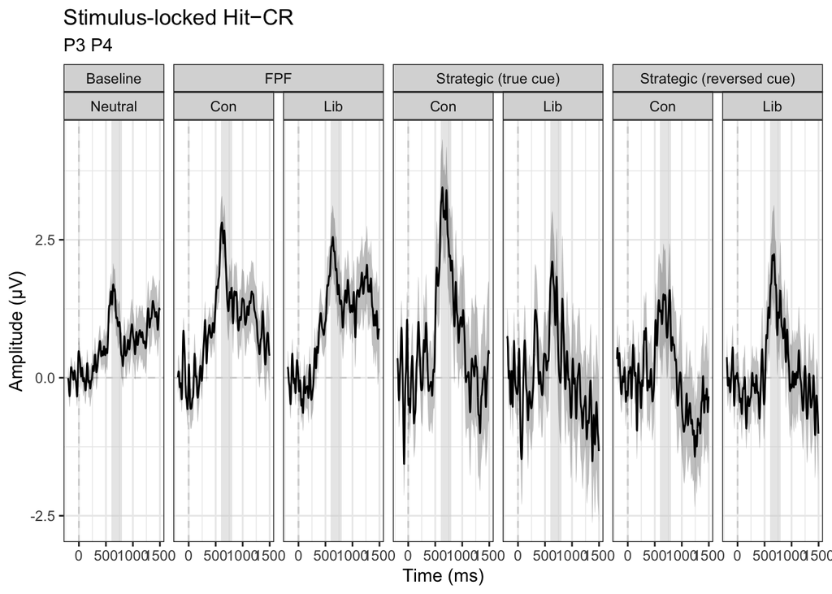

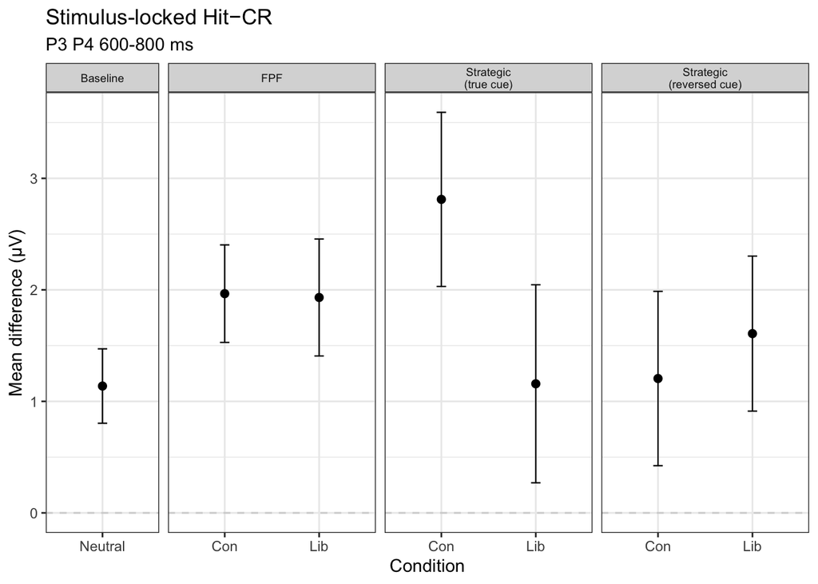

```r
# LPC
erpwave_in = erpwave_df_list$LPC
erpamp_in  = erpamp_df_list$LPC

# ==== plot diff ===============================================================
plot_custom_diff(erpwave_in, erpamp_in,
                 curr_erpname = "LPC",
                 curr_title = glue("Hit{minus}CR"),
                 contrast_var = "resptype", contrast_levels = c("Hit","CR"), save_fig=save_fig)
```

```r
# ==== model: taskcond x hitcr =================================================
diffamp_model_df = collapse_levels(erpamp_in, contrast_var="resptype", type="amp") %>%
  filter(cell_ntrials >= min_n) %>%
  filter(resptype %in% c("Hit","CR"))

get_des(diffamp_model_df, vars = c("task","cond","resptype"))
```

| task | cond | resptype | mean | sd | nsub |
| --- | --- | --- | --- | --- | --- |
| Baseline | Neutral | Hit | 0.2199696 | 4.273324 | 58 |
| Baseline | Neutral | CR | -0.9174075 | 4.547905 | 58 |
| FPF | Con | Hit | 2.2452925 | 5.039294 | 58 |
| FPF | Con | CR | 0.2793681 | 4.799751 | 58 |
| FPF | Lib | Hit | 2.4817852 | 5.534576 | 58 |
| FPF | Lib | CR | 0.5502149 | 4.603214 | 58 |
| Strategic (true cue) | Con | Hit | 4.6449514 | 5.981481 | 25 |
| Strategic (true cue) | Con | CR | 1.8336618 | 4.290396 | 25 |
| Strategic (true cue) | Lib | Hit | 3.1735863 | 6.022195 | 25 |
| Strategic (true cue) | Lib | CR | 2.0159196 | 6.182503 | 25 |

[output cut: 4 more lines]

```r
model.lm = lmer(mean_amp ~ taskcond * resptype * cue + (1|sub) + (1|sub:taskcond) + (1|sub:resptype), data=diffamp_model_df)
model.emm   = emmeans(model.lm, ~ resptype | taskcond * cue, lmer.df = "satterthwaite")
model.pairs = pairs(model.emm)

model.emm; model.pairs
```

```
## taskcond = Baseline Neutral, cue = True:
##  resptype emmean    SE   df lower.CL upper.CL
##  Hit      -0.186 1.020 98.8  -2.2160    1.845
##  CR       -1.627 1.020 98.8  -3.6575    0.403
##
## taskcond = FPF Con, cue = True:
##  resptype emmean    SE   df lower.CL upper.CL
##  Hit       1.434 1.020 98.8  -0.5960    3.465
##  CR       -0.210 1.020 98.8  -2.2407    1.820
##
## taskcond = FPF Lib, cue = True:
##  resptype emmean    SE   df lower.CL upper.CL
##  Hit       1.925 1.020 98.8  -0.1058    3.955
##  CR        0.288 1.020 98.8  -1.7424    2.319
##
## taskcond = Strategic Con, cue = True:
##  resptype emmean    SE   df lower.CL upper.CL
##  Hit       4.645 1.020 98.8   2.6145    6.675
##  CR        1.834 1.020 98.8  -0.1968    3.864
##
## taskcond = Strategic Lib, cue = True:
##  resptype emmean    SE   df lower.CL upper.CL
##  Hit       3.174 1.020 98.8   1.1431    5.204
##  CR        2.016 1.020 98.8  -0.0146    4.046
##
## taskcond = Baseline Neutral, cue = Reversed:
##  resptype emmean    SE   df lower.CL upper.CL
##  Hit       0.527 0.891 98.8  -1.2401    2.294
##  CR       -0.380 0.891 98.8  -2.1471    1.387
##
## taskcond = FPF Con, cue = Reversed:
##  resptype emmean    SE   df lower.CL upper.CL
##  Hit       2.860 0.891 98.8   1.0923    4.627
##  CR        0.650 0.891 98.8  -1.1171    2.418
##
## taskcond = FPF Lib, cue = Reversed:
##  resptype emmean    SE   df lower.CL upper.CL
##  Hit       2.904 0.891 98.8   1.1366    4.671
##  CR        0.749 0.891 98.8  -1.0185    2.516
##
## taskcond = Strategic Con, cue = Reversed:
##  resptype emmean    SE   df lower.CL upper.CL
##  Hit       4.246 0.891 98.8   2.4786    6.013
##  CR        3.041 0.891 98.8   1.2737    4.808
##
## taskcond = Strategic Lib, cue = Reversed:
##  resptype emmean    SE   df lower.CL upper.CL
##  Hit       3.920 0.891 98.8   2.1525    5.687
##  CR        2.312 0.891 98.8   0.5448    4.079
##
## Degrees-of-freedom method: satterthwaite
## Confidence level used: 0.95
```

```
## taskcond = Baseline Neutral, cue = True:
##  contrast estimate    SE  df t.ratio p.value
##  Hit - CR    1.441 0.745 230   1.934  0.0544
##
## taskcond = FPF Con, cue = True:
##  contrast estimate    SE  df t.ratio p.value
##  Hit - CR    1.645 0.745 230   2.206  0.0284
##
## taskcond = FPF Lib, cue = True:
##  contrast estimate    SE  df t.ratio p.value
##  Hit - CR    1.637 0.745 230   2.195  0.0291
##
## taskcond = Strategic Con, cue = True:
##  contrast estimate    SE  df t.ratio p.value
##  Hit - CR    2.811 0.745 230   3.771  0.0002
##
## taskcond = Strategic Lib, cue = True:
##  contrast estimate    SE  df t.ratio p.value
##  Hit - CR    1.158 0.745 230   1.553  0.1218
##
## taskcond = Baseline Neutral, cue = Reversed:
##  contrast estimate    SE  df t.ratio p.value
##  Hit - CR    0.907 0.649 230   1.398  0.1635
##
## taskcond = FPF Con, cue = Reversed:
##  contrast estimate    SE  df t.ratio p.value
##  Hit - CR    2.209 0.649 230   3.405  0.0008
##
## taskcond = FPF Lib, cue = Reversed:
##  contrast estimate    SE  df t.ratio p.value
##  Hit - CR    2.155 0.649 230   3.321  0.0010
##
## taskcond = Strategic Con, cue = Reversed:
##  contrast estimate    SE  df t.ratio p.value
##  Hit - CR    1.205 0.649 230   1.857  0.0646
##
## taskcond = Strategic Lib, cue = Reversed:
##  contrast estimate    SE  df t.ratio p.value
##  Hit - CR    1.608 0.649 230   2.478  0.0139
##
## Degrees-of-freedom method: satterthwaite
```

```r
# ===== contrasts ==============================================================
# [!!!] default order alphabetical: base, FPF con, FPF lib, strategic con, strategic lib
# list specific contrasts so family-wise adjustment isn't too strict
taskcond_pairs_list = list(
  fpfcon_fpflib = c( 0, 1,-1, 0, 0), scon_slib   = c( 0, 0, 0, 1,-1),  # lib vs con within each task
  fpfcon_base   = c(-1, 1, 0, 0, 0), scon_base   = c(-1, 0, 0, 1, 0),  # compare to baseline
  fpflib_base   = c(-1, 0, 1, 0, 0), slib_base   = c(-1, 0, 0, 0, 1),
  fpflib_slib   = c( 0, 0, 1, 0,-1), fpfcon_scon = c( 0, 1, 0,-1, 0)   # FPF vs strategic within lib/con
)

contrast_hitcr = contrast(model.emm, list(hit_cr = c(1,-1)), adjust="holm")   # hit=1, cr=-1 [make sure factor levels are correct]
contrast_hitcr
```

```
## taskcond = Baseline Neutral, cue = True:
##  contrast estimate    SE  df t.ratio p.value
##  hit_cr      1.441 0.745 230   1.934  0.0544
##
## taskcond = FPF Con, cue = True:
##  contrast estimate    SE  df t.ratio p.value
##  hit_cr      1.645 0.745 230   2.206  0.0284
##
## taskcond = FPF Lib, cue = True:
##  contrast estimate    SE  df t.ratio p.value
##  hit_cr      1.637 0.745 230   2.195  0.0291
##
## taskcond = Strategic Con, cue = True:
##  contrast estimate    SE  df t.ratio p.value
##  hit_cr      2.811 0.745 230   3.771  0.0002
##
## taskcond = Strategic Lib, cue = True:
##  contrast estimate    SE  df t.ratio p.value
##  hit_cr      1.158 0.745 230   1.553  0.1218
##
## taskcond = Baseline Neutral, cue = Reversed:
##  contrast estimate    SE  df t.ratio p.value
##  hit_cr      0.907 0.649 230   1.398  0.1635
##
## taskcond = FPF Con, cue = Reversed:
##  contrast estimate    SE  df t.ratio p.value
##  hit_cr      2.209 0.649 230   3.405  0.0008
##
## taskcond = FPF Lib, cue = Reversed:
##  contrast estimate    SE  df t.ratio p.value
##  hit_cr      2.155 0.649 230   3.321  0.0010
##
## taskcond = Strategic Con, cue = Reversed:
##  contrast estimate    SE  df t.ratio p.value
##  hit_cr      1.205 0.649 230   1.857  0.0646
##
## taskcond = Strategic Lib, cue = Reversed:
##  contrast estimate    SE  df t.ratio p.value
##  hit_cr      1.608 0.649 230   2.478  0.0139
##
## Degrees-of-freedom method: satterthwaite
```

```r
# holm within each cue group
contrast(contrast_hitcr, by="cue", adjust = "holm", infer=c(T,T), method = taskcond_pairs_list)  # "none" for unadjusted pval
```

```
## cue = True:
##  contrast      estimate    SE  df lower.CL upper.CL t.ratio p.value
##  fpfcon_fpflib  0.00805 0.924 224   -2.541     2.56   0.009  1.0000
##  scon_slib      1.65362 0.924 224   -0.896     4.20   1.791  0.5977
##  fpfcon_base    0.20314 0.924 224   -2.346     2.75   0.220  1.0000
##  scon_base      1.36980 0.924 224   -1.180     3.92   1.483  0.9759
##  fpflib_base    0.19509 0.924 224   -2.354     2.74   0.211  1.0000
##  slib_base     -0.28382 0.924 224   -2.833     2.27  -0.307  1.0000
##  fpflib_slib    0.47891 0.924 224   -2.070     3.03   0.519  1.0000
##  fpfcon_scon   -1.16666 0.924 224   -3.716     1.38  -1.263  1.0000
##
## cue = Reversed:
##  contrast      estimate    SE  df lower.CL upper.CL t.ratio p.value
##  fpfcon_fpflib  0.05428 0.804 224   -2.165     2.27   0.068  1.0000
##  scon_slib     -0.40280 0.804 224   -2.622     1.82  -0.501  1.0000
##  fpfcon_base    1.30234 0.804 224   -0.917     3.52   1.620  0.8528
##  scon_base      0.29791 0.804 224   -1.921     2.52   0.371  1.0000
##  fpflib_base    1.24806 0.804 224   -0.971     3.47   1.553  0.8534
##  slib_base      0.70071 0.804 224   -1.518     2.92   0.872  1.0000
##  fpflib_slib    0.54735 0.804 224   -1.672     2.77   0.681  1.0000
##  fpfcon_scon    1.00443 0.804 224   -1.214     3.22   1.250  1.0000
##
## Degrees-of-freedom method: satterthwaite
## Confidence level used: 0.95
## Conf-level adjustment: bonferroni method for 8 estimates
## P value adjustment: holm method for 8 tests
```

```r
summary(contrast_hitcr, by="cue", adjust="holm", infer=c(T,T))
```

|  | contrast | taskcond | cue | estimate | SE | df | lower.CL | upper.CL | t.ratio | p.value |
| --- | --- | --- | --- | --- | --- | --- | --- | --- | --- | --- |
| 1 | hit_cr | Baseline Neutral | True | 1.4414897 | 0.7454775 | 230.1669 | -0.49478199 | 3.377761 | 1.933646 | 0.113449778 |
| 2 | hit_cr | FPF Con | True | 1.6446318 | 0.7454775 | 230.1669 | -0.29163991 | 3.580904 | 2.206146 | 0.113449778 |
| 3 | hit_cr | FPF Lib | True | 1.6365787 | 0.7454775 | 230.1669 | -0.29969301 | 3.572850 | 2.195343 | 0.113449778 |
| 4 | hit_cr | Strategic Con | True | 2.8112896 | 0.7454775 | 230.1669 | 0.87501783 | 4.747561 | 3.771126 | 0.001033296 |
| 5 | hit_cr | Strategic Lib | True | 1.1576667 | 0.7454775 | 230.1669 | -0.77860503 | 3.093938 | 1.552920 | 0.121816206 |
| 6 | hit_cr | Baseline Neutral | Reversed | 0.9069887 | 0.6488548 | 230.1669 | -0.77831951 | 2.592297 | 1.397830 | 0.163509834 |
| 7 | hit_cr | FPF Con | Reversed | 2.2093279 | 0.6488548 | 230.1669 | 0.52401970 | 3.894636 | 3.404965 | 0.003903018 |
| 8 | hit_cr | FPF Lib | Reversed | 2.1550488 | 0.6488548 | 230.1669 | 0.46974054 | 3.840357 | 3.321311 | 0.004167502 |
| 9 | hit_cr | Strategic Con | Reversed | 1.2049002 | 0.6488548 | 230.1669 | -0.48040802 | 2.890208 | 1.856964 | 0.129187616 |
| 10 | hit_cr | Strategic Lib | Reversed | 1.6076954 | 0.6488548 | 230.1669 | -0.07761287 | 3.293004 | 2.477743 | 0.041821972 |

```r
get_eff(model=model.lm, model_contrast = contrast_hitcr, type="within")
```

```
## taskcond = Baseline Neutral, cue = True:
##  contrast effect.size    SE  df lower.CL upper.CL
##  hit_cr         0.282 0.146 230 -0.00583    0.569
##
## taskcond = FPF Con, cue = True:
##  contrast effect.size    SE  df lower.CL upper.CL
##  hit_cr         0.321 0.146 230  0.03373    0.609
##
## taskcond = FPF Lib, cue = True:
##  contrast effect.size    SE  df lower.CL upper.CL
##  hit_cr         0.320 0.146 230  0.03216    0.608
##
## taskcond = Strategic Con, cue = True:
##  contrast effect.size    SE  df lower.CL upper.CL
##  hit_cr         0.549 0.147 230  0.26055    0.838
##
## taskcond = Strategic Lib, cue = True:
##  contrast effect.size    SE  df lower.CL upper.CL
##  hit_cr         0.226 0.146 230 -0.06113    0.514
##
## taskcond = Baseline Neutral, cue = Reversed:
##  contrast effect.size    SE  df lower.CL upper.CL
##  hit_cr         0.177 0.127 230 -0.07282    0.427
##
## taskcond = FPF Con, cue = Reversed:
##  contrast effect.size    SE  df lower.CL upper.CL
##  hit_cr         0.432 0.127 230  0.18064    0.683
##
## taskcond = FPF Lib, cue = Reversed:
##  contrast effect.size    SE  df lower.CL upper.CL
##  hit_cr         0.421 0.127 230  0.17009    0.672
##
## taskcond = Strategic Con, cue = Reversed:
##  contrast effect.size    SE  df lower.CL upper.CL
##  hit_cr         0.235 0.127 230 -0.01476    0.486
##
## taskcond = Strategic Lib, cue = Reversed:
##  contrast effect.size    SE  df lower.CL upper.CL
##  hit_cr         0.314 0.127 230  0.06366    0.565
##
## sigma used for effect sizes: 5.116
## Degrees-of-freedom method: inherited from satterthwaite when re-gridding
## Confidence level used: 0.95
```

```r
get_eff(model=model.lm, model_contrast = contrast_hitcr, type="between",by="cue", method=taskcond_pairs_list)
```

```
## cue = True:
##  contrast      effect.size    SE  df lower.CL upper.CL
##  fpfcon_fpflib     0.00157 0.181 224  -0.3541    0.357
##  scon_slib         0.32320 0.181 224  -0.0330    0.679
##  fpfcon_base       0.03970 0.181 224  -0.3160    0.395
##  scon_base         0.26773 0.181 224  -0.0883    0.624
##  fpflib_base       0.03813 0.181 224  -0.3176    0.394
##  slib_base        -0.05547 0.181 224  -0.4112    0.300
##  fpflib_slib       0.09360 0.181 224  -0.2621    0.449
##  fpfcon_scon      -0.22802 0.181 224  -0.5840    0.128
##
## cue = Reversed:
##  contrast      effect.size    SE  df lower.CL upper.CL
##  fpfcon_fpflib     0.01061 0.157 224  -0.2990    0.320
##  scon_slib        -0.07873 0.157 224  -0.3884    0.231
##  fpfcon_base       0.25454 0.157 224  -0.0554    0.565
##  scon_base         0.05823 0.157 224  -0.2514    0.368
##  fpflib_base       0.24393 0.157 224  -0.0660    0.554
##  slib_base         0.13695 0.157 224  -0.1727    0.447
##  fpflib_slib       0.10698 0.157 224  -0.2027    0.417
##  fpfcon_scon       0.19631 0.157 224  -0.1135    0.506
##
## sigma used for effect sizes: 5.116
## Degrees-of-freedom method: inherited from satterthwaite when re-gridding
## Confidence level used: 0.95
```

```r
# full sample, averaged over cue [report base/FPF rows only]
contrast_hitcr_pooled = contrast(emmeans(model.lm, ~ resptype | taskcond, lmer.df = "satterthwaite"), list(hit_cr = c(1,-1)))
summary(contrast_hitcr_pooled[1:3], by=NULL, adjust="holm", infer=c(T,T))   # rows 1-3 = base, FPF con, FPF lib
```

|  | contrast | taskcond | estimate | SE | df | lower.CL | upper.CL | t.ratio | p.value |
| --- | --- | --- | --- | --- | --- | --- | --- | --- | --- |
| 1 | hit_cr | Baseline Neutral | 1.174239 | 0.4941531 | 230.1669 | -0.01746296 | 2.365941 | 2.376266 | 0.0183082869 |
| 2 | hit_cr | FPF Con | 1.926980 | 0.4941531 | 230.1669 | 0.73527769 | 3.118682 | 3.899560 | 0.0003794374 |
| 3 | hit_cr | FPF Lib | 1.895814 | 0.4941531 | 230.1669 | 0.70411156 | 3.087516 | 3.836490 | 0.0003794374 |

```r
contrast(contrast_hitcr_pooled, by=NULL, adjust="holm", infer=c(T,T), method = taskcond_pairs_list[c("fpfcon_fpflib","fpfcon_base","fpflib_base")])
```

```
##  contrast      estimate    SE  df lower.CL upper.CL t.ratio p.value
##  fpfcon_fpflib   0.0312 0.612 224   -1.445     1.51   0.051  0.9594
##  fpfcon_base     0.7527 0.612 224   -0.724     2.23   1.230  0.6604
##  fpflib_base     0.7216 0.612 224   -0.755     2.20   1.179  0.6604
##
## Results are averaged over the levels of: cue
## Degrees-of-freedom method: satterthwaite
## Confidence level used: 0.95
## Conf-level adjustment: bonferroni method for 3 estimates
## P value adjustment: holm method for 3 tests
```

```r
get_eff(model=model.lm, model_contrast = contrast_hitcr_pooled[1:3], type="within")
```

```
##  contrast                effect.size     SE  df lower.CL upper.CL
##  hit_cr Baseline Neutral       0.230 0.0968 230   0.0387    0.420
##  hit_cr FPF Con                0.377 0.0972 230   0.1850    0.568
##  hit_cr FPF Lib                0.371 0.0972 230   0.1790    0.562
##
## Results are averaged over the levels of: cue
## sigma used for effect sizes: 5.116
## Degrees-of-freedom method: inherited from satterthwaite when re-gridding
## Confidence level used: 0.95
```

```r
get_eff(model=model.lm, model_contrast = contrast_hitcr_pooled, type="between", method=taskcond_pairs_list[c("fpfcon_fpflib","fpfcon_base","fpflib_base")])
```

```
##  contrast      effect.size   SE  df lower.CL upper.CL
##  fpfcon_fpflib     0.00609 0.12 224  -0.2297    0.242
##  fpfcon_base       0.14712 0.12 224  -0.0888    0.383
##  fpflib_base       0.14103 0.12 224  -0.0949    0.377
##
## Results are averaged over the levels of: cue
## sigma used for effect sizes: 5.116
## Degrees-of-freedom method: inherited from satterthwaite when re-gridding
## Confidence level used: 0.95
```

```r
# true vs reversed cue
contrast(contrast_hitcr, by=NULL, adjust="holm", infer=c(T,T), method=cue_list[1:3])   # strategic
```

```
##  contrast                   estimate    SE  df lower.CL upper.CL t.ratio
##  strategic con-lib true-rev     2.06 1.220 224   -0.897     5.01   1.680
##  con strategic true-rev         1.61 0.988 230   -0.777     3.99   1.625
##  lib strategic true-rev        -0.45 0.988 230   -2.833     1.93  -0.455
##  p.value
##   0.2833
##   0.2833
##   0.6493
##
## Degrees-of-freedom method: satterthwaite
## Confidence level used: 0.95
## Conf-level adjustment: bonferroni method for 3 estimates
## P value adjustment: holm method for 3 tests
```

```r
contrast(contrast_hitcr, by=NULL, adjust="none", infer=c(T,T), method=cue_list[4:5])   # consistency check, base/FPF
```

```
##  contrast             estimate    SE  df lower.CL upper.CL t.ratio p.value
##  FPF con-lib true-rev  -0.0462 1.220 224    -2.46     2.37  -0.038  0.9699
##  baseline true-rev      0.5345 0.988 230    -1.41     2.48   0.541  0.5892
##
## Degrees-of-freedom method: satterthwaite
## Confidence level used: 0.95
```

```r
get_eff(model=model.lm, model_contrast = contrast_hitcr, type="between", method=cue_list)
```

```
##  contrast                     effect.size    SE  df lower.CL upper.CL
##  (strategic con-lib true-rev)     0.40193 0.240 224  -0.0702    0.874
##  (con strategic true-rev)         0.31397 0.193 230  -0.0671    0.695
##  (lib strategic true-rev)        -0.08796 0.193 230  -0.4686    0.293
##  (FPF con-lib true-rev)          -0.00903 0.239 224  -0.4806    0.463
##  (baseline true-rev)              0.10447 0.193 230  -0.2762    0.485
##
## sigma used for effect sizes: 5.116
## Degrees-of-freedom method: inherited from satterthwaite when re-gridding
## Confidence level used: 0.95
```

### FPF old/new item effect

- erp: FN400, maybe LPC
- collapse: is_old
- model: amp ~ cond x is_old
- contrasts: new items lib-con; old items lib-con; interaction
- [NEW] erpwave: is_old x libcon *?????????????*
- diffwave/diffamp: lib-con, old and new items on separate panels [?????]

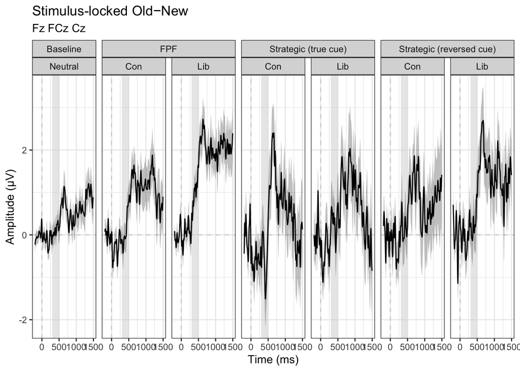

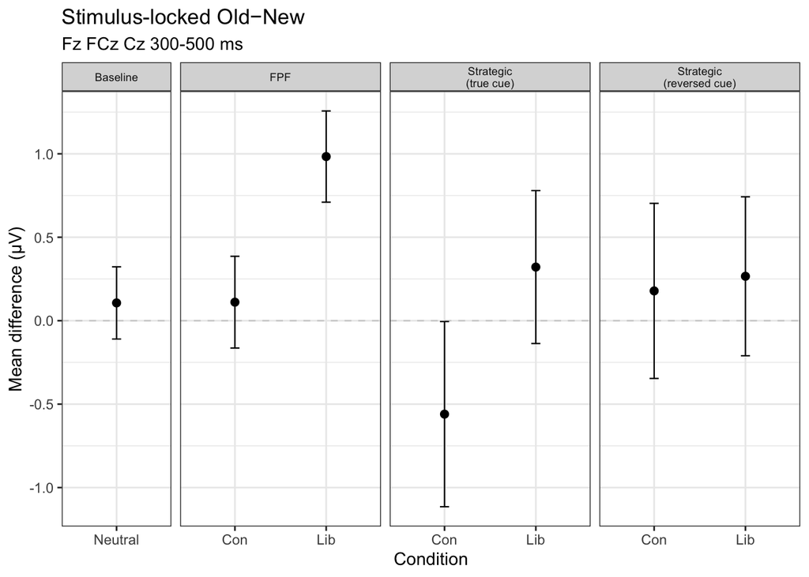

```r
# FN400
erpwave_in = erpwave_df_list$FN400
erpamp_in  = erpamp_df_list$FN400

# ==== plot diff ===============================================================
plot_custom_diff(erpwave_in, erpamp_in,
                 curr_erpname = "FN400",
                 curr_title = glue("Old{minus}New"),
                 contrast_var = "is_old", contrast_levels = c("Old","New"), save_fig=save_fig)
```

```r
# ==== model: all taskcond x is_old ============================================
diffamp_model_df = collapse_levels(erpamp_in, contrast_var="is_old", type="amp") %>%
  filter(cell_ntrials >= min_n) %>%
  mutate(is_old = factor(is_old, levels=c("Old","New")))  # specify levels for contrast order in model

get_des(diffamp_model_df, vars = c("task","cond","is_old"))
```

| task | cond | is_old | mean | sd | nsub |
| --- | --- | --- | --- | --- | --- |
| Baseline | Neutral | Old | -12.08430 | 5.296493 | 58 |
| Baseline | Neutral | New | -12.19085 | 5.169447 | 58 |
| FPF | Con | Old | -11.84866 | 5.368823 | 58 |
| FPF | Con | New | -11.95963 | 5.321456 | 58 |
| FPF | Lib | Old | -11.34634 | 5.280579 | 58 |
| FPF | Lib | New | -12.32986 | 5.289586 | 58 |
| Strategic (true cue) | Con | Old | -11.81792 | 5.662336 | 25 |
| Strategic (true cue) | Con | New | -11.25783 | 4.736900 | 25 |
| Strategic (true cue) | Lib | Old | -11.07484 | 5.154450 | 25 |
| Strategic (true cue) | Lib | New | -11.39621 | 4.967908 | 25 |

[output cut: 4 more lines]

```r
model.lm = lmer(mean_amp ~ taskcond * is_old * cue + (1|sub) + (1|sub:taskcond) + (1|sub:is_old), data=diffamp_model_df)
# replace `taskcond` with `task*cond` but need to get around empty cell issue from baseline
model.emm = emmeans(model.lm, ~ is_old | taskcond * cue, lmer.df = "satterthwaite")   # is there an old/new effect in each taskcond
model.pairs = pairs(model.emm)
model.emm; model.pairs
```

```
## taskcond = Baseline Neutral, cue = True:
##  is_old emmean    SE   df lower.CL upper.CL
##  Old     -12.3 1.070 75.1    -14.4   -10.17
##  New     -12.5 1.070 75.1    -14.6   -10.34
##
## taskcond = FPF Con, cue = True:
##  is_old emmean    SE   df lower.CL upper.CL
##  Old     -12.4 1.070 75.1    -14.5   -10.28
##  New     -12.0 1.070 75.1    -14.1    -9.87
##
## taskcond = FPF Lib, cue = True:
##  is_old emmean    SE   df lower.CL upper.CL
##  Old     -11.9 1.070 75.1    -14.0    -9.76
##  New     -13.0 1.070 75.1    -15.1   -10.84
##
## taskcond = Strategic Con, cue = True:
##  is_old emmean    SE   df lower.CL upper.CL
##  Old     -11.8 1.070 75.1    -13.9    -9.69
##  New     -11.3 1.070 75.1    -13.4    -9.13
##
## taskcond = Strategic Lib, cue = True:
##  is_old emmean    SE   df lower.CL upper.CL
##  Old     -11.1 1.070 75.1    -13.2    -8.95
##  New     -11.4 1.070 75.1    -13.5    -9.27
##
## taskcond = Baseline Neutral, cue = Reversed:
##  is_old emmean    SE   df lower.CL upper.CL
##  Old     -11.9 0.928 75.1    -13.8   -10.08
##  New     -12.0 0.928 75.1    -13.8   -10.13
##
## taskcond = FPF Con, cue = Reversed:
##  is_old emmean    SE   df lower.CL upper.CL
##  Old     -11.4 0.928 75.1    -13.3    -9.58
##  New     -11.9 0.928 75.1    -13.8   -10.08
##
## taskcond = FPF Lib, cue = Reversed:
##  is_old emmean    SE   df lower.CL upper.CL
##  Old     -10.9 0.928 75.1    -12.8    -9.09
##  New     -11.9 0.928 75.1    -13.7   -10.00
##
## taskcond = Strategic Con, cue = Reversed:
##  is_old emmean    SE   df lower.CL upper.CL
##  Old     -10.9 0.928 75.1    -12.8    -9.09
##  New     -11.1 0.928 75.1    -13.0    -9.27
##
## taskcond = Strategic Lib, cue = Reversed:
##  is_old emmean    SE   df lower.CL upper.CL
##  Old     -10.2 0.928 75.1    -12.0    -8.34
##  New     -10.5 0.928 75.1    -12.3    -8.61
##
## Degrees-of-freedom method: satterthwaite
## Confidence level used: 0.95
```

```
## taskcond = Baseline Neutral, cue = True:
##  contrast  estimate   SE  df t.ratio p.value
##  Old - New   0.1770 0.46 278   0.385  0.7007
##
## taskcond = FPF Con, cue = True:
##  contrast  estimate   SE  df t.ratio p.value
##  Old - New  -0.4092 0.46 278  -0.890  0.3743
##
## taskcond = FPF Lib, cue = True:
##  contrast  estimate   SE  df t.ratio p.value
##  Old - New   1.0755 0.46 278   2.339  0.0201
##
## taskcond = Strategic Con, cue = True:
##  contrast  estimate   SE  df t.ratio p.value
##  Old - New  -0.5601 0.46 278  -1.218  0.2242
##
## taskcond = Strategic Lib, cue = True:
##  contrast  estimate   SE  df t.ratio p.value
##  Old - New   0.3214 0.46 278   0.699  0.4852
##
## taskcond = Baseline Neutral, cue = Reversed:
##  contrast  estimate   SE  df t.ratio p.value
##  Old - New   0.0532 0.40 278   0.133  0.8943
##
## taskcond = FPF Con, cue = Reversed:
##  contrast  estimate   SE  df t.ratio p.value
##  Old - New   0.5051 0.40 278   1.262  0.2080
##
## taskcond = FPF Lib, cue = Reversed:
##  contrast  estimate   SE  df t.ratio p.value
##  Old - New   0.9139 0.40 278   2.283  0.0232
##
## taskcond = Strategic Con, cue = Reversed:
##  contrast  estimate   SE  df t.ratio p.value
##  Old - New   0.1785 0.40 278   0.446  0.6559
##
## taskcond = Strategic Lib, cue = Reversed:
##  contrast  estimate   SE  df t.ratio p.value
##  Old - New   0.2661 0.40 278   0.665  0.5066
##
## Degrees-of-freedom method: satterthwaite
```

```r
# ===== contrasts ==============================================================
# [!!!] default order alphabetical: base, FPF con, FPF lib, strategic con, strategic lib
# list specific contrasts so family-wise adjustment isn't too strict
taskcond_pairs_list = list(
  fpfcon_fpflib = c( 0, 1,-1, 0, 0), scon_slib   = c( 0, 0, 0, 1,-1),  # lib vs con within each task
  fpfcon_base   = c(-1, 1, 0, 0, 0), scon_base   = c(-1, 0, 0, 1, 0),  # compare to baseline
  fpflib_base   = c(-1, 0, 1, 0, 0), slib_base   = c(-1, 0, 0, 0, 1),
  fpflib_slib   = c( 0, 0, 1, 0,-1), fpfcon_scon = c( 0, 1, 0,-1, 0)   # FPF vs strategic within lib/con
)

contrast_isold = contrast(model.emm, list(old_new = c(1,-1)), adjust="holm")   # old=1,new=-1 [make sure factor levels are correct]
contrast_isold
```

```
## taskcond = Baseline Neutral, cue = True:
##  contrast estimate   SE  df t.ratio p.value
##  old_new    0.1770 0.46 278   0.385  0.7007
##
## taskcond = FPF Con, cue = True:
##  contrast estimate   SE  df t.ratio p.value
##  old_new   -0.4092 0.46 278  -0.890  0.3743
##
## taskcond = FPF Lib, cue = True:
##  contrast estimate   SE  df t.ratio p.value
##  old_new    1.0755 0.46 278   2.339  0.0201
##
## taskcond = Strategic Con, cue = True:
##  contrast estimate   SE  df t.ratio p.value
##  old_new   -0.5601 0.46 278  -1.218  0.2242
##
## taskcond = Strategic Lib, cue = True:
##  contrast estimate   SE  df t.ratio p.value
##  old_new    0.3214 0.46 278   0.699  0.4852
##
## taskcond = Baseline Neutral, cue = Reversed:
##  contrast estimate   SE  df t.ratio p.value
##  old_new    0.0532 0.40 278   0.133  0.8943
##
## taskcond = FPF Con, cue = Reversed:
##  contrast estimate   SE  df t.ratio p.value
##  old_new    0.5051 0.40 278   1.262  0.2080
##
## taskcond = FPF Lib, cue = Reversed:
##  contrast estimate   SE  df t.ratio p.value
##  old_new    0.9139 0.40 278   2.283  0.0232
##
## taskcond = Strategic Con, cue = Reversed:
##  contrast estimate   SE  df t.ratio p.value
##  old_new    0.1785 0.40 278   0.446  0.6559
##
## taskcond = Strategic Lib, cue = Reversed:
##  contrast estimate   SE  df t.ratio p.value
##  old_new    0.2661 0.40 278   0.665  0.5066
##
## Degrees-of-freedom method: satterthwaite
```

```r
# within each cue group
contrast(contrast_isold, by="cue", adjust = "holm", infer=c(T,T), method = taskcond_pairs_list)  # "none" for unadjusted pval
```

```
## cue = True:
##  contrast      estimate    SE  df lower.CL upper.CL t.ratio p.value
##  fpfcon_fpflib  -1.4847 0.636 224   -3.240    0.270  -2.335  0.1632
##  scon_slib      -0.8815 0.636 224   -2.636    0.873  -1.387  1.0000
##  fpfcon_base    -0.5862 0.636 224   -2.341    1.169  -0.922  1.0000
##  scon_base      -0.7370 0.636 224   -2.492    1.018  -1.159  1.0000
##  fpflib_base     0.8985 0.636 224   -0.856    2.653   1.413  1.0000
##  slib_base       0.1444 0.636 224   -1.610    1.899   0.227  1.0000
##  fpflib_slib     0.7541 0.636 224   -1.001    2.509   1.186  1.0000
##  fpfcon_scon     0.1509 0.636 224   -1.604    1.906   0.237  1.0000
##
## cue = Reversed:
##  contrast      estimate    SE  df lower.CL upper.CL t.ratio p.value
##  fpfcon_fpflib  -0.4088 0.553 224   -1.936    1.119  -0.739  1.0000
##  scon_slib      -0.0876 0.553 224   -1.615    1.440  -0.158  1.0000
##  fpfcon_base     0.4518 0.553 224   -1.076    1.979   0.817  1.0000
##  scon_base       0.1253 0.553 224   -1.402    1.653   0.226  1.0000
##  fpflib_base     0.8606 0.553 224   -0.667    2.388   1.555  0.9701
##  slib_base       0.2129 0.553 224   -1.315    1.740   0.385  1.0000
##  fpflib_slib     0.6477 0.553 224   -0.880    2.175   1.171  1.0000
##  fpfcon_scon     0.3265 0.553 224   -1.201    1.854   0.590  1.0000
##
## Degrees-of-freedom method: satterthwaite
## Confidence level used: 0.95
## Conf-level adjustment: bonferroni method for 8 estimates
## P value adjustment: holm method for 8 tests
```

```r
summary(contrast_isold, by="cue", adjust="holm", infer=c(T,T))
```

|  | contrast | taskcond | cue | estimate | SE | df | lower.CL | upper.CL | t.ratio | p.value |
| --- | --- | --- | --- | --- | --- | --- | --- | --- | --- | --- |
| 1 | old_new | Baseline Neutral | True | 0.17695030 | 0.4598272 | 277.8185 | -1.0156765 | 1.3695771 | 0.3848191 | 1.0000000 |
| 2 | old_new | FPF Con | True | -0.40922165 | 0.4598272 | 277.8185 | -1.6018485 | 0.7834052 | -0.8899466 | 1.0000000 |
| 3 | old_new | FPF Lib | True | 1.07546157 | 0.4598272 | 277.8185 | -0.1171653 | 2.2680884 | 2.3388385 | 0.1002644 |
| 4 | old_new | Strategic Con | True | -0.56009510 | 0.4598272 | 277.8185 | -1.7527219 | 0.6325317 | -1.2180556 | 0.8969451 |
| 5 | old_new | Strategic Lib | True | 0.32136922 | 0.4598272 | 277.8185 | -0.8712576 | 1.5139961 | 0.6988913 | 1.0000000 |
| 6 | old_new | Baseline Neutral | Reversed | 0.05321367 | 0.4002282 | 277.8185 | -0.9848347 | 1.0912621 | 0.1329583 | 1.0000000 |
| 7 | old_new | FPF Con | Reversed | 0.50505337 | 0.4002282 | 277.8185 | -0.5329950 | 1.5431018 | 1.2619135 | 0.8321533 |
| 8 | old_new | FPF Lib | Reversed | 0.91386319 | 0.4002282 | 277.8185 | -0.1241852 | 1.9519116 | 2.2833553 | 0.1158230 |
| 9 | old_new | Strategic Con | Reversed | 0.17850882 | 0.4002282 | 277.8185 | -0.8595396 | 1.2165572 | 0.4460176 | 1.0000000 |
| 10 | old_new | Strategic Lib | Reversed | 0.26614186 | 0.4002282 | 277.8185 | -0.7719065 | 1.3041903 | 0.6649753 | 1.0000000 |

```r
get_eff(model=model.lm, model_contrast = contrast_isold, type="within")
```

```
## taskcond = Baseline Neutral, cue = True:
##  contrast effect.size     SE  df lower.CL upper.CL
##  old_new      0.03321 0.0863 278  -0.1367   0.2031
##
## taskcond = FPF Con, cue = True:
##  contrast effect.size     SE  df lower.CL upper.CL
##  old_new     -0.07679 0.0863 278  -0.2467   0.0931
##
## taskcond = FPF Lib, cue = True:
##  contrast effect.size     SE  df lower.CL upper.CL
##  old_new      0.20181 0.0865 278   0.0315   0.3721
##
## taskcond = Strategic Con, cue = True:
##  contrast effect.size     SE  df lower.CL upper.CL
##  old_new     -0.10510 0.0863 278  -0.2751   0.0649
##
## taskcond = Strategic Lib, cue = True:
##  contrast effect.size     SE  df lower.CL upper.CL
##  old_new      0.06031 0.0863 278  -0.1096   0.2302
##
## taskcond = Baseline Neutral, cue = Reversed:
##  contrast effect.size     SE  df lower.CL upper.CL
##  old_new      0.00999 0.0751 278  -0.1379   0.1578
##
## taskcond = FPF Con, cue = Reversed:
##  contrast effect.size     SE  df lower.CL upper.CL
##  old_new      0.09477 0.0752 278  -0.0532   0.2427
##
## taskcond = FPF Lib, cue = Reversed:
##  contrast effect.size     SE  df lower.CL upper.CL
##  old_new      0.17149 0.0753 278   0.0233   0.3197
##
## taskcond = Strategic Con, cue = Reversed:
##  contrast effect.size     SE  df lower.CL upper.CL
##  old_new      0.03350 0.0751 278  -0.1144   0.1814
##
## taskcond = Strategic Lib, cue = Reversed:
##  contrast effect.size     SE  df lower.CL upper.CL
##  old_new      0.04994 0.0751 278  -0.0979   0.1978
##
## sigma used for effect sizes: 5.329
## Degrees-of-freedom method: inherited from satterthwaite when re-gridding
## Confidence level used: 0.95
```

```r
get_eff(model=model.lm, model_contrast = contrast_isold, type="between",by="cue", method=taskcond_pairs_list)
```

```
## cue = True:
##  contrast      effect.size    SE  df lower.CL upper.CL
##  fpfcon_fpflib     -0.2786 0.120 224  -0.5143  -0.0429
##  scon_slib         -0.1654 0.119 224  -0.4007   0.0699
##  fpfcon_base       -0.1100 0.119 224  -0.3452   0.1252
##  scon_base         -0.1383 0.119 224  -0.3735   0.0969
##  fpflib_base        0.1686 0.119 224  -0.0667   0.4039
##  slib_base          0.0271 0.119 224  -0.2080   0.2622
##  fpflib_slib        0.1415 0.119 224  -0.0937   0.3767
##  fpfcon_scon        0.0283 0.119 224  -0.2068   0.2634
##
## cue = Reversed:
##  contrast      effect.size    SE  df lower.CL upper.CL
##  fpfcon_fpflib     -0.0767 0.104 224  -0.2814   0.1280
##  scon_slib         -0.0164 0.104 224  -0.2211   0.1882
##  fpfcon_base        0.0848 0.104 224  -0.1199   0.2895
##  scon_base          0.0235 0.104 224  -0.1811   0.2281
##  fpflib_base        0.1615 0.104 224  -0.0433   0.3663
##  slib_base          0.0400 0.104 224  -0.1647   0.2446
##  fpflib_slib        0.1215 0.104 224  -0.0832   0.3263
##  fpfcon_scon        0.0613 0.104 224  -0.1434   0.2659
##
## sigma used for effect sizes: 5.329
## Degrees-of-freedom method: inherited from satterthwaite when re-gridding
## Confidence level used: 0.95
```

```r
# full sample, averaged over cue [report base/FPF rows only]
contrast_isold_pooled = contrast(emmeans(model.lm, ~ is_old | taskcond, lmer.df = "satterthwaite"), list(old_new = c(1,-1)))
summary(contrast_isold_pooled[1:3], by=NULL, adjust="holm", infer=c(T,T))   # rows 1-3 = base, FPF con, FPF lib
```

|  | contrast | taskcond | estimate | SE | df | lower.CL | upper.CL | t.ratio | p.value |
| --- | --- | --- | --- | --- | --- | --- | --- | --- | --- |
| 1 | old_new | Baseline Neutral | 0.11508198 | 0.3048047 | 277.8185 | -0.6190598 | 0.8492238 | 0.3775597 | 1.000000000 |
| 2 | old_new | FPF Con | 0.04791586 | 0.3048047 | 277.8185 | -0.6862260 | 0.7820577 | 0.1572018 | 1.000000000 |
| 3 | old_new | FPF Lib | 0.99466238 | 0.3048047 | 277.8185 | 0.2605205 | 1.7288042 | 3.2632775 | 0.003717072 |

```r
contrast(contrast_isold_pooled, by=NULL, adjust="holm", infer=c(T,T), method = taskcond_pairs_list[c("fpfcon_fpflib","fpfcon_base","fpflib_base")])
```

```
##  contrast      estimate    SE  df lower.CL upper.CL t.ratio p.value
##  fpfcon_fpflib  -0.9467 0.421 224   -1.963   0.0697  -2.247  0.0769
##  fpfcon_base    -0.0672 0.421 224   -1.084   0.9493  -0.159  0.8735
##  fpflib_base     0.8796 0.421 224   -0.137   1.8960   2.087  0.0769
##
## Results are averaged over the levels of: cue
## Degrees-of-freedom method: satterthwaite
## Confidence level used: 0.95
## Conf-level adjustment: bonferroni method for 3 estimates
## P value adjustment: holm method for 3 tests
```

```r
get_eff(model=model.lm, model_contrast = contrast_isold_pooled[1:3], type="within")
```

```
##  contrast                 effect.size     SE  df lower.CL upper.CL
##  old_new Baseline Neutral     0.02160 0.0572 278  -0.0910    0.134
##  old_new FPF Con              0.00899 0.0572 278  -0.1036    0.122
##  old_new FPF Lib              0.18665 0.0575 278   0.0735    0.300
##
## Results are averaged over the levels of: cue
## sigma used for effect sizes: 5.329
## Degrees-of-freedom method: inherited from satterthwaite when re-gridding
## Confidence level used: 0.95
```

```r
get_eff(model=model.lm, model_contrast = contrast_isold_pooled, type="between", method=taskcond_pairs_list[c("fpfcon_fpflib","fpfcon_base","fpflib_base")])
```

```
##  contrast      effect.size     SE  df lower.CL upper.CL
##  fpfcon_fpflib     -0.1777 0.0793 224 -0.33384  -0.0215
##  fpfcon_base       -0.0126 0.0791 224 -0.16844   0.1432
##  fpflib_base        0.1651 0.0792 224  0.00892   0.3212
##
## Results are averaged over the levels of: cue
## sigma used for effect sizes: 5.329
## Degrees-of-freedom method: inherited from satterthwaite when re-gridding
## Confidence level used: 0.95
```

```r
# true vs reversed cue
contrast(contrast_isold, by=NULL, adjust="holm", infer=c(T,T), method=cue_list[1:3])   # strategic
```

```
##  contrast                   estimate    SE  df lower.CL upper.CL t.ratio
##  strategic con-lib true-rev  -0.7938 0.843 224    -2.83     1.24  -0.942
##  con strategic true-rev      -0.7386 0.610 278    -2.21     0.73  -1.212
##  lib strategic true-rev       0.0552 0.610 278    -1.41     1.52   0.091
##  p.value
##   0.6945
##   0.6801
##   0.9279
##
## Degrees-of-freedom method: satterthwaite
## Confidence level used: 0.95
## Conf-level adjustment: bonferroni method for 3 estimates
## P value adjustment: holm method for 3 tests
```

```r
contrast(contrast_isold, by=NULL, adjust="none", infer=c(T,T), method=cue_list[4:5])   # consistency check, base/FPF
```

```
##  contrast             estimate    SE  df lower.CL upper.CL t.ratio p.value
##  FPF con-lib true-rev   -1.076 0.843 224    -2.74    0.585  -1.277  0.2031
##  baseline true-rev       0.124 0.610 278    -1.08    1.324   0.203  0.8393
##
## Degrees-of-freedom method: satterthwaite
## Confidence level used: 0.95
```

```r
get_eff(model=model.lm, model_contrast = contrast_isold, type="between", method=cue_list)
```

```
##  contrast                     effect.size    SE  df lower.CL upper.CL
##  (strategic con-lib true-rev)     -0.1490 0.158 224   -0.461   0.1628
##  (con strategic true-rev)         -0.1386 0.114 278   -0.364   0.0867
##  (lib strategic true-rev)          0.0104 0.114 278   -0.215   0.2356
##  (FPF con-lib true-rev)           -0.2019 0.158 224   -0.514   0.1100
##  (baseline true-rev)               0.0232 0.114 278   -0.202   0.2484
##
## sigma used for effect sizes: 5.329
## Degrees-of-freedom method: inherited from satterthwaite when re-gridding
## Confidence level used: 0.95
```

```r
# ==== model: cond x is_old, FPF only ==========================================
diffamp_model_df = collapse_levels(erpamp_in %>% filter(task=="FPF"),
                                   contrast_var="is_old", type="amp") %>%
  filter(cell_ntrials >= min_n) %>%
  mutate(is_old = factor(is_old, levels=c("Old","New")),
         cond   = factor(cond,   levels=c("Lib","Con")))

get_des(diffamp_model_df, vars = c("taskcond","is_old"))
```

| taskcond | is_old | mean | sd | nsub |
| --- | --- | --- | --- | --- |
| FPF Con | Old | -11.84866 | 5.368823 | 58 |
| FPF Con | New | -11.95963 | 5.321456 | 58 |
| FPF Lib | Old | -11.34634 | 5.280579 | 58 |
| FPF Lib | New | -12.32986 | 5.289586 | 58 |

```r
model.lm = lmer(mean_amp ~ cond * is_old + (1|sub) + (1|sub:cond) + (1|sub:is_old), data=diffamp_model_df)
model.emm   = emmeans(model.lm, ~ is_old | cond, lmer.df = "satterthwaite")  # old-new within each cond
model.pairs = pairs(model.emm)
model.emm; model.pairs
```

```
## cond = Lib:
##  is_old emmean    SE   df lower.CL upper.CL
##  Old     -11.3 0.698 64.4    -12.7    -9.95
##  New     -12.3 0.698 64.4    -13.7   -10.94
##
## cond = Con:
##  is_old emmean    SE   df lower.CL upper.CL
##  Old     -11.8 0.698 64.4    -13.2   -10.45
##  New     -12.0 0.698 64.4    -13.4   -10.57
##
## Degrees-of-freedom method: satterthwaite
## Confidence level used: 0.95
```

```
## cond = Lib:
##  contrast  estimate    SE  df t.ratio p.value
##  Old - New    0.984 0.274 114   3.588  0.0005
##
## cond = Con:
##  contrast  estimate    SE  df t.ratio p.value
##  Old - New    0.111 0.274 114   0.405  0.6864
##
## Degrees-of-freedom method: satterthwaite
```

```r
model.emm2   = emmeans(model.lm, ~ cond | is_old, lmer.df = "satterthwaite")  # lib-con within each status
model.pairs2 = pairs(model.emm2)
model.emm2; model.pairs2
```

```
## is_old = Old:
##  cond emmean    SE   df lower.CL upper.CL
##  Lib   -11.3 0.698 64.4    -12.7    -9.95
##  Con   -11.8 0.698 64.4    -13.2   -10.45
##
## is_old = New:
##  cond emmean    SE   df lower.CL upper.CL
##  Lib   -12.3 0.698 64.4    -13.7   -10.94
##  Con   -12.0 0.698 64.4    -13.4   -10.57
##
## Degrees-of-freedom method: satterthwaite
## Confidence level used: 0.95
```

```
## is_old = Old:
##  contrast  estimate    SE  df t.ratio p.value
##  Lib - Con    0.502 0.281 114   1.785  0.0769
##
## is_old = New:
##  contrast  estimate    SE  df t.ratio p.value
##  Lib - Con   -0.370 0.281 114  -1.316  0.1909
##
## Degrees-of-freedom method: satterthwaite
```

```r
summary(model.pairs2, by=NULL, adjust="holm", infer=c(T,T))
```

|  | contrast | is_old | estimate | SE | df | lower.CL | upper.CL | t.ratio | p.value |
| --- | --- | --- | --- | --- | --- | --- | --- | --- | --- |
| 1 | Lib - Con | Old | 0.5023161 | 0.2814032 | 113.8169 | -0.1368748 | 1.1415071 | 1.785040 | 0.1538370 |
| 2 | Lib - Con | New | -0.3702322 | 0.2814032 | 113.8169 | -1.0094232 | 0.2689587 | -1.315664 | 0.1909307 |

```r
contrast_out = contrast(emmeans(model.lm, ~ is_old * cond, lmer.df = "satterthwaite"),
         adjust="holm", interaction="pairwise", infer=c(T,T))
contrast_out
```

```
##  is_old_pairwise cond_pairwise estimate    SE   df lower.CL upper.CL t.ratio
##  Old - New       Lib - Con        0.873 0.388 57.1   0.0965     1.65   2.251
##  p.value
##   0.0282
##
## Degrees-of-freedom method: satterthwaite
## Confidence level used: 0.95
```

```r
get_eff(model = model.lm, model_contrast = contrast_out, type="within")
```

```
##  contrast              effect.size     SE   df lower.CL upper.CL
##  (Old - New Lib - Con)       0.164 0.0733 57.1   0.0173    0.311
##
## sigma used for effect sizes: 5.315
## Degrees-of-freedom method: inherited from satterthwaite when re-gridding
## Confidence level used: 0.95
```

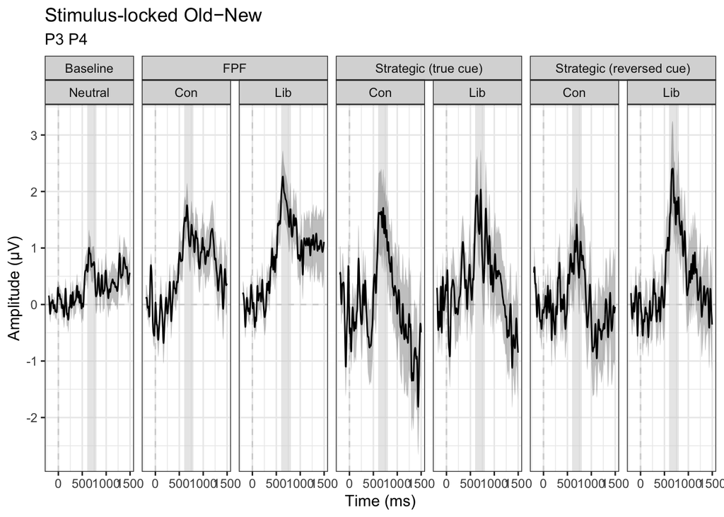

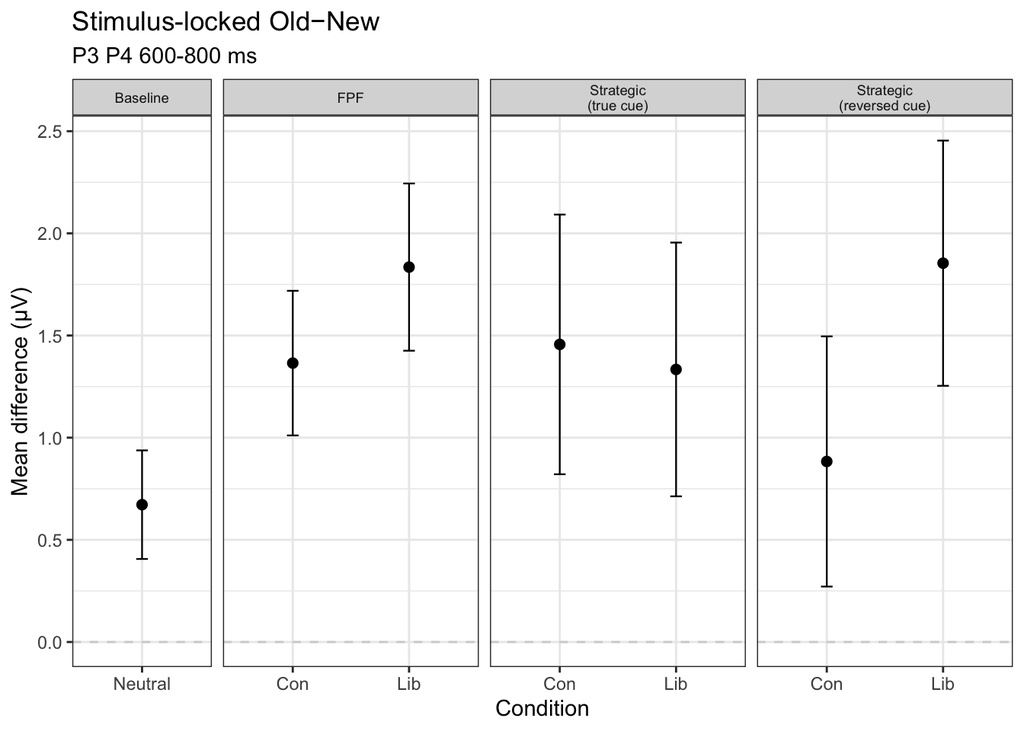

```r
# LPC
erpwave_in = erpwave_df_list$LPC
erpamp_in  = erpamp_df_list$LPC

# ==== plot diff ===============================================================
plot_custom_diff(erpwave_in, erpamp_in,
                 curr_erpname = "LPC",
                 curr_title = glue("Old{minus}New"),
                 contrast_var = "is_old", contrast_levels = c("Old","New"), save_fig=save_fig)
```

```r
# ==== model: all taskcond x is_old ============================================
diffamp_model_df = collapse_levels(erpamp_in, contrast_var="is_old", type="amp") %>%
  filter(cell_ntrials >= min_n) %>%
  mutate(is_old = factor(is_old, levels=c("Old","New")))  # specify levels for contrast order in model

get_des(diffamp_model_df, vars = c("task","cond","is_old"))
```

| task | cond | is_old | mean | sd | nsub |
| --- | --- | --- | --- | --- | --- |
| Baseline | Neutral | Old | -0.3318646 | 4.147576 | 58 |
| Baseline | Neutral | New | -1.0038914 | 4.605929 | 58 |
| FPF | Con | Old | 1.6589333 | 4.781966 | 58 |
| FPF | Con | New | 0.2939971 | 4.579314 | 58 |
| FPF | Lib | Old | 2.0918314 | 5.227081 | 58 |
| FPF | Lib | New | 0.2570114 | 4.826006 | 58 |
| Strategic (true cue) | Con | Old | 3.3250988 | 5.513376 | 25 |
| Strategic (true cue) | Con | New | 1.8686254 | 4.262238 | 25 |
| Strategic (true cue) | Lib | Old | 3.1276958 | 5.418866 | 25 |
| Strategic (true cue) | Lib | New | 1.7937547 | 5.431474 | 25 |

[output cut: 4 more lines]

```r
model.lm = lmer(mean_amp ~ taskcond * is_old * cue + (1|sub) + (1|sub:taskcond) + (1|sub:is_old), data=diffamp_model_df)
model.emm   = emmeans(model.lm, ~ is_old | taskcond * cue, lmer.df = "satterthwaite")
model.pairs = pairs(model.emm)
model.emm; model.pairs
```

```
## taskcond = Baseline Neutral, cue = True:
##  is_old  emmean    SE   df lower.CL upper.CL
##  Old    -1.0487 0.987 84.7  -3.0114    0.914
##  New    -1.5769 0.987 84.7  -3.5396    0.386
##
## taskcond = FPF Con, cue = True:
##  is_old  emmean    SE   df lower.CL upper.CL
##  Old     1.0716 0.987 84.7  -0.8911    3.034
##  New     0.0569 0.987 84.7  -1.9058    2.020
##
## taskcond = FPF Lib, cue = True:
##  is_old  emmean    SE   df lower.CL upper.CL
##  Old     1.7222 0.987 84.7  -0.2405    3.685
##  New    -0.0874 0.987 84.7  -2.0501    1.875
##
## taskcond = Strategic Con, cue = True:
##  is_old  emmean    SE   df lower.CL upper.CL
##  Old     3.3251 0.987 84.7   1.3624    5.288
##  New     1.8686 0.987 84.7  -0.0941    3.831
##
## taskcond = Strategic Lib, cue = True:
##  is_old  emmean    SE   df lower.CL upper.CL
##  Old     3.1277 0.987 84.7   1.1650    5.090
##  New     1.7938 0.987 84.7  -0.1690    3.756
##
## taskcond = Baseline Neutral, cue = Reversed:
##  is_old  emmean    SE   df lower.CL upper.CL
##  Old     0.2112 0.859 84.7  -1.4972    1.919
##  New    -0.5698 0.859 84.7  -2.2781    1.139
##
## taskcond = FPF Con, cue = Reversed:
##  is_old  emmean    SE   df lower.CL upper.CL
##  Old     2.1039 0.859 84.7   0.3955    3.812
##  New     0.4736 0.859 84.7  -1.2348    2.182
##
## taskcond = FPF Lib, cue = Reversed:
##  is_old  emmean    SE   df lower.CL upper.CL
##  Old     2.3718 0.859 84.7   0.6635    4.080
##  New     0.5179 0.859 84.7  -1.1904    2.226
##
## taskcond = Strategic Con, cue = Reversed:
##  is_old  emmean    SE   df lower.CL upper.CL
##  Old     3.8858 0.859 84.7   2.1774    5.594
##  New     3.0022 0.859 84.7   1.2939    4.711
##
## taskcond = Strategic Lib, cue = Reversed:
##  is_old  emmean    SE   df lower.CL upper.CL
##  Old     4.2473 0.859 84.7   2.5389    5.956
##  New     2.3933 0.859 84.7   0.6850    4.102
##
## Degrees-of-freedom method: satterthwaite
## Confidence level used: 0.95
```

```
## taskcond = Baseline Neutral, cue = True:
##  contrast  estimate    SE  df t.ratio p.value
##  Old - New    0.528 0.591 254   0.894  0.3723
##
## taskcond = FPF Con, cue = True:
##  contrast  estimate    SE  df t.ratio p.value
##  Old - New    1.015 0.591 254   1.717  0.0872
##
## taskcond = FPF Lib, cue = True:
##  contrast  estimate    SE  df t.ratio p.value
##  Old - New    1.810 0.591 254   3.062  0.0024
##
## taskcond = Strategic Con, cue = True:
##  contrast  estimate    SE  df t.ratio p.value
##  Old - New    1.456 0.591 254   2.464  0.0144
##
## taskcond = Strategic Lib, cue = True:
##  contrast  estimate    SE  df t.ratio p.value
##  Old - New    1.334 0.591 254   2.257  0.0248
##
## taskcond = Baseline Neutral, cue = Reversed:
##  contrast  estimate    SE  df t.ratio p.value
##  Old - New    0.781 0.514 254   1.518  0.1302
##
## taskcond = FPF Con, cue = Reversed:
##  contrast  estimate    SE  df t.ratio p.value
##  Old - New    1.630 0.514 254   3.169  0.0017
##
## taskcond = FPF Lib, cue = Reversed:
##  contrast  estimate    SE  df t.ratio p.value
##  Old - New    1.854 0.514 254   3.604  0.0004
##
## taskcond = Strategic Con, cue = Reversed:
##  contrast  estimate    SE  df t.ratio p.value
##  Old - New    0.884 0.514 254   1.718  0.0871
##
## taskcond = Strategic Lib, cue = Reversed:
##  contrast  estimate    SE  df t.ratio p.value
##  Old - New    1.854 0.514 254   3.604  0.0004
##
## Degrees-of-freedom method: satterthwaite
```

```r
# ==== model: cond x is_old, FPF only ==========================================
diffamp_model_df = collapse_levels(erpamp_in %>% filter(task=="FPF"),
                                   contrast_var="is_old", type="amp") %>%
  filter(cell_ntrials >= min_n) %>%
  mutate(is_old = factor(is_old, levels=c("Old","New")),
         cond   = factor(cond,   levels=c("Lib","Con")))

get_des(diffamp_model_df, vars = c("taskcond","is_old"))
```

| taskcond | is_old | mean | sd | nsub |
| --- | --- | --- | --- | --- |
| FPF Con | Old | 1.6589333 | 4.781966 | 58 |
| FPF Con | New | 0.2939971 | 4.579314 | 58 |
| FPF Lib | Old | 2.0918314 | 5.227081 | 58 |
| FPF Lib | New | 0.2570114 | 4.826006 | 58 |

```r
model.lm = lmer(mean_amp ~ cond * is_old + (1|sub) + (1|sub:cond) + (1|sub:is_old), data=diffamp_model_df)
model.emm   = emmeans(model.lm, ~ is_old | cond, lmer.df = "satterthwaite")
model.pairs = pairs(model.emm)
model.emm; model.pairs
```

```
## cond = Lib:
##  is_old emmean    SE   df lower.CL upper.CL
##  Old     2.092 0.638 73.8    0.820     3.36
##  New     0.257 0.638 73.8   -1.014     1.53
##
## cond = Con:
##  is_old emmean    SE   df lower.CL upper.CL
##  Old     1.659 0.638 73.8    0.388     2.93
##  New     0.294 0.638 73.8   -0.977     1.57
##
## Degrees-of-freedom method: satterthwaite
## Confidence level used: 0.95
```

```
## cond = Lib:
##  contrast  estimate    SE  df t.ratio p.value
##  Old - New     1.83 0.383 107   4.796 <0.0001
##
## cond = Con:
##  contrast  estimate    SE  df t.ratio p.value
##  Old - New     1.36 0.383 107   3.568  0.0005
##
## Degrees-of-freedom method: satterthwaite
```

```r
model.emm2   = emmeans(model.lm, ~ cond | is_old, lmer.df = "satterthwaite")  # lib-con within each status
model.pairs2 = pairs(model.emm2)
model.emm2; model.pairs2
```

```
## is_old = Old:
##  cond emmean    SE   df lower.CL upper.CL
##  Lib   2.092 0.638 73.8    0.820     3.36
##  Con   1.659 0.638 73.8    0.388     2.93
##
## is_old = New:
##  cond emmean    SE   df lower.CL upper.CL
##  Lib   0.257 0.638 73.8   -1.014     1.53
##  Con   0.294 0.638 73.8   -0.977     1.57
##
## Degrees-of-freedom method: satterthwaite
## Confidence level used: 0.95
```

```
## is_old = Old:
##  contrast  estimate    SE  df t.ratio p.value
##  Lib - Con    0.433 0.331 114   1.307  0.1938
##
## is_old = New:
##  contrast  estimate    SE  df t.ratio p.value
##  Lib - Con   -0.037 0.331 114  -0.112  0.9113
##
## Degrees-of-freedom method: satterthwaite
```

```r
summary(model.pairs2, by=NULL, adjust="holm", infer=c(T,T))
```

|  | contrast | is_old | estimate | SE | df | lower.CL | upper.CL | t.ratio | p.value |
| --- | --- | --- | --- | --- | --- | --- | --- | --- | --- |
| 1 | Lib - Con | Old | 0.43289807 | 0.3311632 | 113.9723 | -0.3193060 | 1.1851022 | 1.3072045 | 0.3875488 |
| 2 | Lib - Con | New | -0.03698571 | 0.3311632 | 113.9723 | -0.7891898 | 0.7152184 | -0.1116842 | 0.9112702 |

```r
contrast_out = contrast(emmeans(model.lm, ~ is_old * cond, lmer.df = "satterthwaite"),
         adjust="holm", interaction="pairwise", infer=c(T,T))
contrast_out
```

```
##  is_old_pairwise cond_pairwise estimate    SE df lower.CL upper.CL t.ratio
##  Old - New       Lib - Con         0.47 0.465 57   -0.461      1.4   1.011
##  p.value
##   0.3162
##
## Degrees-of-freedom method: satterthwaite
## Confidence level used: 0.95
```

```r
get_eff(model = model.lm, model_contrast = contrast_out, type="within")
```

```
##  contrast              effect.size     SE df lower.CL upper.CL
##  (Old - New Lib - Con)      0.0967 0.0957 57   -0.095    0.288
##
## sigma used for effect sizes: 4.859
## Degrees-of-freedom method: inherited from satterthwaite when re-gridding
## Confidence level used: 0.95
```

# RESP

### overall error effect

- erp: ERN
- collapse: incorrect vs correct
- diff: incorrect-correct
- model: amp ~ is_correct x taskcond
- erpwave/erpamp: full taskcond x resptype
- diffwave/diffamp: diff x taskcond

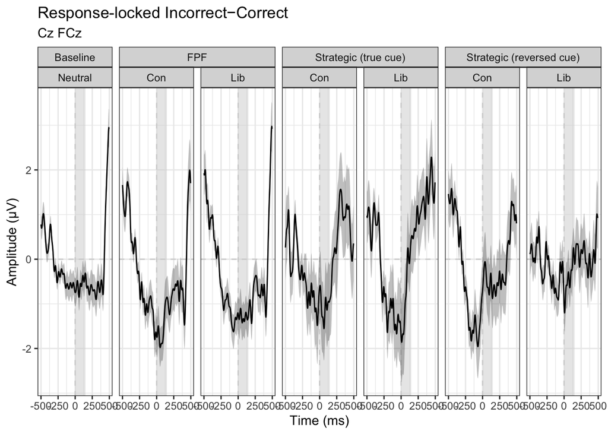

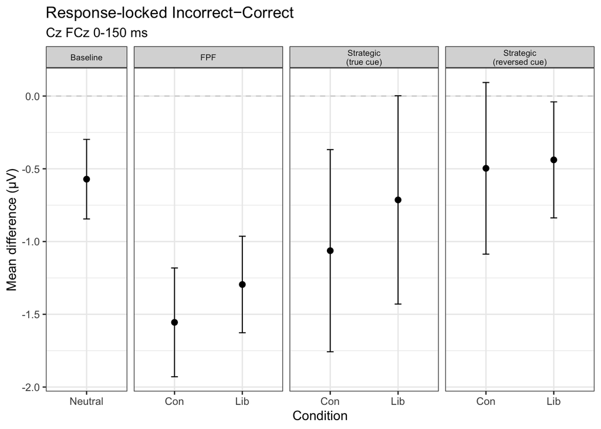

```r
# ERN
erpwave_in = erpwave_df_list$ERN
erpamp_in  = erpamp_df_list$ERN

# ==== plot diff ===============================================================
plot_custom_diff(erpwave_in, erpamp_in,
                 curr_erpname = "ERN",
                 curr_title = glue("Incorrect{minus}Correct"),
                 contrast_var = "is_correct", contrast_levels = c("Incorrect","Correct"), save_fig=save_fig)
```

```r
# ==== model: taskcond x is_correct ============================================
diffamp_model_df = collapse_levels(erpamp_in, contrast_var="is_correct", type="amp") %>%
  filter(cell_ntrials >= min_n) %>%
  mutate(is_correct = factor(is_correct, levels=c("Incorrect","Correct")))

get_des(diffamp_model_df, vars = c("task","cond","is_correct"))
```

| task | cond | is_correct | mean | sd | nsub |
| --- | --- | --- | --- | --- | --- |
| Baseline | Neutral | Incorrect | -0.2712979 | 3.261897 | 58 |
| Baseline | Neutral | Correct | 0.2999748 | 3.480991 | 58 |
| FPF | Con | Incorrect | 0.8635664 | 3.968994 | 58 |
| FPF | Con | Correct | 2.4189503 | 4.159838 | 58 |
| FPF | Lib | Incorrect | 0.8475757 | 4.111704 | 58 |
| FPF | Lib | Correct | 2.1427001 | 4.310399 | 58 |
| Strategic (true cue) | Con | Incorrect | 1.8987647 | 3.642925 | 25 |
| Strategic (true cue) | Con | Correct | 2.9614918 | 3.826559 | 25 |
| Strategic (true cue) | Lib | Incorrect | 3.1106485 | 3.575470 | 25 |
| Strategic (true cue) | Lib | Correct | 3.8244492 | 4.086769 | 25 |

[output cut: 4 more lines]

```r
model.lm = lmer(mean_amp ~ taskcond * is_correct * cue + (1|sub) + (1|sub:taskcond) + (1|sub:is_correct), data=diffamp_model_df)
model.emm   = emmeans(model.lm, ~ is_correct | taskcond * cue, lmer.df = "satterthwaite")
model.pairs = pairs(model.emm)
model.emm; model.pairs
```

```
## taskcond = Baseline Neutral, cue = True:
##  is_correct  emmean    SE  df lower.CL upper.CL
##  Incorrect   0.1506 0.762 101   -1.362    1.663
##  Correct     0.7239 0.762 101   -0.788    2.236
##
## taskcond = FPF Con, cue = True:
##  is_correct  emmean    SE  df lower.CL upper.CL
##  Incorrect   1.6570 0.762 101    0.145    3.169
##  Correct     3.1587 0.762 101    1.646    4.671
##
## taskcond = FPF Lib, cue = True:
##  is_correct  emmean    SE  df lower.CL upper.CL
##  Incorrect   1.3088 0.762 101   -0.204    2.821
##  Correct     2.6168 0.762 101    1.104    4.129
##
## taskcond = Strategic Con, cue = True:
##  is_correct  emmean    SE  df lower.CL upper.CL
##  Incorrect   1.8988 0.762 101    0.386    3.411
##  Correct     2.9615 0.762 101    1.449    4.474
##
## taskcond = Strategic Lib, cue = True:
##  is_correct  emmean    SE  df lower.CL upper.CL
##  Incorrect   3.1106 0.762 101    1.598    4.623
##  Correct     3.8244 0.762 101    2.312    5.337
##
## taskcond = Baseline Neutral, cue = Reversed:
##  is_correct  emmean    SE  df lower.CL upper.CL
##  Incorrect  -0.5909 0.664 101   -1.907    0.725
##  Correct    -0.0212 0.664 101   -1.338    1.295
##
## taskcond = FPF Con, cue = Reversed:
##  is_correct  emmean    SE  df lower.CL upper.CL
##  Incorrect   0.2625 0.664 101   -1.054    1.579
##  Correct     1.8586 0.664 101    0.542    3.175
##
## taskcond = FPF Lib, cue = Reversed:
##  is_correct  emmean    SE  df lower.CL upper.CL
##  Incorrect   0.4982 0.664 101   -0.818    1.815
##  Correct     1.7835 0.664 101    0.467    3.100
##
## taskcond = Strategic Con, cue = Reversed:
##  is_correct  emmean    SE  df lower.CL upper.CL
##  Incorrect   2.4695 0.664 101    1.153    3.786
##  Correct     2.9662 0.664 101    1.650    4.283
##
## taskcond = Strategic Lib, cue = Reversed:
##  is_correct  emmean    SE  df lower.CL upper.CL
##  Incorrect   1.6080 0.664 101    0.292    2.924
##  Correct     2.0467 0.664 101    0.730    3.363
##
## Degrees-of-freedom method: satterthwaite
## Confidence level used: 0.95
```

```
## taskcond = Baseline Neutral, cue = True:
##  contrast            estimate    SE  df t.ratio p.value
##  Incorrect - Correct   -0.573 0.561 251  -1.021  0.3080
##
## taskcond = FPF Con, cue = True:
##  contrast            estimate    SE  df t.ratio p.value
##  Incorrect - Correct   -1.502 0.561 251  -2.676  0.0079
##
## taskcond = FPF Lib, cue = True:
##  contrast            estimate    SE  df t.ratio p.value
##  Incorrect - Correct   -1.308 0.561 251  -2.331  0.0206
##
## taskcond = Strategic Con, cue = True:
##  contrast            estimate    SE  df t.ratio p.value
##  Incorrect - Correct   -1.063 0.561 251  -1.893  0.0594
##
## taskcond = Strategic Lib, cue = True:
##  contrast            estimate    SE  df t.ratio p.value
##  Incorrect - Correct   -0.714 0.561 251  -1.272  0.2046
##
## taskcond = Baseline Neutral, cue = Reversed:
##  contrast            estimate    SE  df t.ratio p.value
##  Incorrect - Correct   -0.570 0.489 251  -1.166  0.2446
##
## taskcond = FPF Con, cue = Reversed:
##  contrast            estimate    SE  df t.ratio p.value
##  Incorrect - Correct   -1.596 0.489 251  -3.267  0.0012
##
## taskcond = FPF Lib, cue = Reversed:
##  contrast            estimate    SE  df t.ratio p.value
##  Incorrect - Correct   -1.285 0.489 251  -2.631  0.0090
##
## taskcond = Strategic Con, cue = Reversed:
##  contrast            estimate    SE  df t.ratio p.value
##  Incorrect - Correct   -0.497 0.489 251  -1.017  0.3103
##
## taskcond = Strategic Lib, cue = Reversed:
##  contrast            estimate    SE  df t.ratio p.value
##  Incorrect - Correct   -0.439 0.489 251  -0.898  0.3701
##
## Degrees-of-freedom method: satterthwaite
```

```r
# ===== contrasts ==============================================================
# [!!!] default order alphabetical: base, FPF con, FPF lib, strategic con, strategic lib
# list specific contrasts so family-wise adjustment isn't too strict
taskcond_pairs_list = list(
  fpfcon_fpflib = c( 0, 1,-1, 0, 0), scon_slib   = c( 0, 0, 0, 1,-1),  # lib vs con within each task
  fpfcon_base   = c(-1, 1, 0, 0, 0), scon_base   = c(-1, 0, 0, 1, 0),  # compare to baseline
  fpflib_base   = c(-1, 0, 1, 0, 0), slib_base   = c(-1, 0, 0, 0, 1),
  fpflib_slib   = c( 0, 0, 1, 0,-1), fpfcon_scon = c( 0, 1, 0,-1, 0)   # FPF vs strategic within lib/con
)

contrast_iscorrect = contrast(model.emm, list(incorrect_correct = c(1,-1)), adjust="holm")   # incorrect=1, correct=-1 [make sure factor levels are correct]
contrast_iscorrect
```

```
## taskcond = Baseline Neutral, cue = True:
##  contrast          estimate    SE  df t.ratio p.value
##  incorrect_correct   -0.573 0.561 251  -1.021  0.3080
##
## taskcond = FPF Con, cue = True:
##  contrast          estimate    SE  df t.ratio p.value
##  incorrect_correct   -1.502 0.561 251  -2.676  0.0079
##
## taskcond = FPF Lib, cue = True:
##  contrast          estimate    SE  df t.ratio p.value
##  incorrect_correct   -1.308 0.561 251  -2.331  0.0206
##
## taskcond = Strategic Con, cue = True:
##  contrast          estimate    SE  df t.ratio p.value
##  incorrect_correct   -1.063 0.561 251  -1.893  0.0594
##
## taskcond = Strategic Lib, cue = True:
##  contrast          estimate    SE  df t.ratio p.value
##  incorrect_correct   -0.714 0.561 251  -1.272  0.2046
##
## taskcond = Baseline Neutral, cue = Reversed:
##  contrast          estimate    SE  df t.ratio p.value
##  incorrect_correct   -0.570 0.489 251  -1.166  0.2446
##
## taskcond = FPF Con, cue = Reversed:
##  contrast          estimate    SE  df t.ratio p.value
##  incorrect_correct   -1.596 0.489 251  -3.267  0.0012
##
## taskcond = FPF Lib, cue = Reversed:
##  contrast          estimate    SE  df t.ratio p.value
##  incorrect_correct   -1.285 0.489 251  -2.631  0.0090
##
## taskcond = Strategic Con, cue = Reversed:
##  contrast          estimate    SE  df t.ratio p.value
##  incorrect_correct   -0.497 0.489 251  -1.017  0.3103
##
## taskcond = Strategic Lib, cue = Reversed:
##  contrast          estimate    SE  df t.ratio p.value
##  incorrect_correct   -0.439 0.489 251  -0.898  0.3701
##
## Degrees-of-freedom method: satterthwaite
```

```r
# within each cue group
contrast(contrast_iscorrect, by="cue", adjust="holm", infer=c(T,T), method = taskcond_pairs_list)  # "none" for unadjusted pval
```

```
## cue = True:
##  contrast      estimate    SE  df lower.CL upper.CL t.ratio p.value
##  fpfcon_fpflib  -0.1936 0.724 224    -2.19    1.804  -0.268  1.0000
##  scon_slib      -0.3489 0.724 224    -2.35    1.649  -0.482  1.0000
##  fpfcon_base    -0.9284 0.724 224    -2.93    1.070  -1.283  1.0000
##  scon_base      -0.4894 0.724 224    -2.49    1.509  -0.676  1.0000
##  fpflib_base    -0.7347 0.724 224    -2.73    1.263  -1.015  1.0000
##  slib_base      -0.1405 0.724 224    -2.14    1.858  -0.194  1.0000
##  fpflib_slib    -0.5942 0.724 224    -2.59    1.404  -0.821  1.0000
##  fpfcon_scon    -0.4389 0.724 224    -2.44    1.559  -0.606  1.0000
##
## cue = Reversed:
##  contrast      estimate    SE  df lower.CL upper.CL t.ratio p.value
##  fpfcon_fpflib  -0.3107 0.630 224    -2.05    1.428  -0.493  1.0000
##  scon_slib      -0.0580 0.630 224    -1.80    1.681  -0.092  1.0000
##  fpfcon_base    -1.0263 0.630 224    -2.77    0.713  -1.629  0.7329
##  scon_base       0.0731 0.630 224    -1.67    1.812   0.116  1.0000
##  fpflib_base    -0.7156 0.630 224    -2.45    1.023  -1.136  1.0000
##  slib_base       0.1311 0.630 224    -1.61    1.870   0.208  1.0000
##  fpflib_slib    -0.8467 0.630 224    -2.59    0.892  -1.344  1.0000
##  fpfcon_scon    -1.0994 0.630 224    -2.84    0.640  -1.745  0.6587
##
## Degrees-of-freedom method: satterthwaite
## Confidence level used: 0.95
## Conf-level adjustment: bonferroni method for 8 estimates
## P value adjustment: holm method for 8 tests
```

```r
summary(contrast_iscorrect, by="cue", adjust="holm", infer=c(T,T))
```

|  | contrast | taskcond | cue | estimate | SE | df | lower.CL | upper.CL | t.ratio | p.value |
| --- | --- | --- | --- | --- | --- | --- | --- | --- | --- | --- |
| 1 | incorrect_correct | Baseline Neutral | True | -0.5733032 | 0.5612508 | 251.4734 | -2.030041 | 0.88343482 | -1.0214742 | 0.409235642 |
| 2 | incorrect_correct | FPF Con | True | -1.5016768 | 0.5612508 | 251.4733 | -2.958415 | -0.04493878 | -2.6755897 | 0.039748071 |
| 3 | incorrect_correct | FPF Lib | True | -1.3080295 | 0.5612508 | 251.4733 | -2.764767 | 0.14870851 | -2.3305616 | 0.082271709 |
| 4 | incorrect_correct | Strategic Con | True | -1.0627271 | 0.5612508 | 251.4733 | -2.519465 | 0.39401087 | -1.8934979 | 0.178318740 |
| 5 | incorrect_correct | Strategic Lib | True | -0.7138007 | 0.5612508 | 251.4733 | -2.170539 | 0.74293727 | -1.2718036 | 0.409235642 |
| 6 | incorrect_correct | Baseline Neutral | Reversed | -0.5697344 | 0.4885061 | 251.4733 | -1.837662 | 0.69819331 | -1.1662790 | 0.733819650 |
| 7 | incorrect_correct | FPF Con | Reversed | -1.5960711 | 0.4885061 | 251.4733 | -2.863999 | -0.32814345 | -3.2672492 | 0.006186276 |
| 8 | incorrect_correct | FPF Lib | Reversed | -1.2853479 | 0.4885061 | 251.4733 | -2.553276 | -0.01742025 | -2.6311810 | 0.036137981 |
| 9 | incorrect_correct | Strategic Con | Reversed | -0.4966503 | 0.4885061 | 251.4733 | -1.764578 | 0.77127736 | -1.0166717 | 0.733819650 |
| 10 | incorrect_correct | Strategic Lib | Reversed | -0.4386449 | 0.4885061 | 251.4733 | -1.706573 | 0.82928273 | -0.8979314 | 0.733819650 |

```r
get_eff(model=model.lm, model_contrast = contrast_iscorrect, type="within")
```

```
## taskcond = Baseline Neutral, cue = True:
##  contrast          effect.size    SE  df lower.CL upper.CL
##  incorrect_correct      -0.150 0.147 251   -0.441   0.1397
##
## taskcond = FPF Con, cue = True:
##  contrast          effect.size    SE  df lower.CL upper.CL
##  incorrect_correct      -0.394 0.148 251   -0.685  -0.1030
##
## taskcond = FPF Lib, cue = True:
##  contrast          effect.size    SE  df lower.CL upper.CL
##  incorrect_correct      -0.343 0.148 251   -0.634  -0.0525
##
## taskcond = Strategic Con, cue = True:
##  contrast          effect.size    SE  df lower.CL upper.CL
##  incorrect_correct      -0.279 0.147 251   -0.569   0.0116
##
## taskcond = Strategic Lib, cue = True:
##  contrast          effect.size    SE  df lower.CL upper.CL
##  incorrect_correct      -0.187 0.147 251   -0.477   0.1029
##
## taskcond = Baseline Neutral, cue = Reversed:
##  contrast          effect.size    SE  df lower.CL upper.CL
##  incorrect_correct      -0.149 0.128 251   -0.402   0.1031
##
## taskcond = FPF Con, cue = Reversed:
##  contrast          effect.size    SE  df lower.CL upper.CL
##  incorrect_correct      -0.419 0.129 251   -0.672  -0.1651
##
## taskcond = FPF Lib, cue = Reversed:
##  contrast          effect.size    SE  df lower.CL upper.CL
##  incorrect_correct      -0.337 0.129 251   -0.590  -0.0840
##
## taskcond = Strategic Con, cue = Reversed:
##  contrast          effect.size    SE  df lower.CL upper.CL
##  incorrect_correct      -0.130 0.128 251   -0.383   0.1222
##
## taskcond = Strategic Lib, cue = Reversed:
##  contrast          effect.size    SE  df lower.CL upper.CL
##  incorrect_correct      -0.115 0.128 251   -0.368   0.1374
##
## sigma used for effect sizes: 3.812
## Degrees-of-freedom method: inherited from satterthwaite when re-gridding
## Confidence level used: 0.95
```

```r
get_eff(model=model.lm, model_contrast = contrast_iscorrect, type="between",by="cue", method=taskcond_pairs_list)
```

```
## cue = True:
##  contrast      effect.size    SE  df lower.CL upper.CL
##  fpfcon_fpflib     -0.0508 0.190 224   -0.425   0.3234
##  scon_slib         -0.0915 0.190 224   -0.466   0.2827
##  fpfcon_base       -0.2435 0.190 224   -0.618   0.1309
##  scon_base         -0.1284 0.190 224   -0.503   0.2459
##  fpflib_base       -0.1927 0.190 224   -0.567   0.1816
##  slib_base         -0.0369 0.190 224   -0.411   0.3373
##  fpflib_slib       -0.1559 0.190 224   -0.530   0.2184
##  fpfcon_scon       -0.1152 0.190 224   -0.489   0.2591
##
## cue = Reversed:
##  contrast      effect.size    SE  df lower.CL upper.CL
##  fpfcon_fpflib     -0.0815 0.165 224   -0.407   0.2442
##  scon_slib         -0.0152 0.165 224   -0.341   0.3105
##  fpfcon_base       -0.2692 0.165 224   -0.595   0.0568
##  scon_base          0.0192 0.165 224   -0.307   0.3449
##  fpflib_base       -0.1877 0.165 224   -0.514   0.1381
##  slib_base          0.0344 0.165 224   -0.291   0.3601
##  fpflib_slib       -0.2221 0.165 224   -0.548   0.1038
##  fpfcon_scon       -0.2884 0.165 224   -0.615   0.0377
##
## sigma used for effect sizes: 3.812
## Degrees-of-freedom method: inherited from satterthwaite when re-gridding
## Confidence level used: 0.95
```

```r
# full sample, averaged over cue [report base/FPF rows only]
contrast_iscorrect_pooled = contrast(emmeans(model.lm, ~ is_correct | taskcond, lmer.df = "satterthwaite"), list(incorrect_correct = c(1,-1)))
summary(contrast_iscorrect_pooled[1:3], by=NULL, adjust="holm", infer=c(T,T))   # rows 1-3 = base, FPF con, FPF lib
```

|  | contrast | taskcond | estimate | SE | df | lower.CL | upper.CL | t.ratio | p.value |
| --- | --- | --- | --- | --- | --- | --- | --- | --- | --- |
| 1 | incorrect_correct | Baseline Neutral | -0.5715188 | 0.3720351 | 251.4733 | -1.468161 | 0.3251240 | -1.536196 | 0.1257476155 |
| 2 | incorrect_correct | FPF Con | -1.5488739 | 0.3720351 | 251.4733 | -2.445517 | -0.6522312 | -4.163246 | 0.0001293987 |
| 3 | incorrect_correct | FPF Lib | -1.2966887 | 0.3720351 | 251.4733 | -2.193331 | -0.4000460 | -3.485393 | 0.0011593150 |

```r
contrast(contrast_iscorrect_pooled, by=NULL, adjust="holm", infer=c(T,T), method = taskcond_pairs_list[c("fpfcon_fpflib","fpfcon_base","fpflib_base")])
```

```
##  contrast      estimate   SE  df lower.CL upper.CL t.ratio p.value
##  fpfcon_fpflib   -0.252 0.48 224    -1.41    0.905  -0.526  0.5997
##  fpfcon_base     -0.977 0.48 224    -2.13    0.180  -2.037  0.1285
##  fpflib_base     -0.725 0.48 224    -1.88    0.432  -1.511  0.2642
##
## Results are averaged over the levels of: cue
## Degrees-of-freedom method: satterthwaite
## Confidence level used: 0.95
## Conf-level adjustment: bonferroni method for 3 estimates
## P value adjustment: holm method for 3 tests
```

```r
get_eff(model=model.lm, model_contrast = contrast_iscorrect_pooled[1:3], type="within")
```

```
##  contrast                           effect.size     SE  df lower.CL upper.CL
##  incorrect_correct Baseline Neutral      -0.150 0.0977 251   -0.342   0.0425
##  incorrect_correct FPF Con               -0.406 0.0984 251   -0.600  -0.2126
##  incorrect_correct FPF Lib               -0.340 0.0981 251   -0.533  -0.1469
##
## Results are averaged over the levels of: cue
## sigma used for effect sizes: 3.812
## Degrees-of-freedom method: inherited from satterthwaite when re-gridding
## Confidence level used: 0.95
```

```r
get_eff(model=model.lm, model_contrast = contrast_iscorrect_pooled, type="between", method=taskcond_pairs_list[c("fpfcon_fpflib","fpfcon_base","fpflib_base")])
```

```
##  contrast      effect.size    SE  df lower.CL upper.CL
##  fpfcon_fpflib     -0.0662 0.126 224   -0.314   0.1819
##  fpfcon_base       -0.2564 0.126 224   -0.505  -0.0079
##  fpflib_base       -0.1902 0.126 224   -0.439   0.0581
##
## Results are averaged over the levels of: cue
## sigma used for effect sizes: 3.812
## Degrees-of-freedom method: inherited from satterthwaite when re-gridding
## Confidence level used: 0.95
```

```r
# true vs reversed cue
contrast(contrast_iscorrect, by=NULL, adjust="holm", infer=c(T,T), method=cue_list[1:3])   # strategic
```

```
##  contrast                   estimate    SE  df lower.CL upper.CL t.ratio
##  strategic con-lib true-rev   -0.291 0.960 224    -2.61     2.02  -0.303
##  con strategic true-rev       -0.566 0.744 251    -2.36     1.23  -0.761
##  lib strategic true-rev       -0.275 0.744 251    -2.07     1.52  -0.370
##  p.value
##   1.0000
##   1.0000
##   1.0000
##
## Degrees-of-freedom method: satterthwaite
## Confidence level used: 0.95
## Conf-level adjustment: bonferroni method for 3 estimates
## P value adjustment: holm method for 3 tests
```

```r
contrast(contrast_iscorrect, by=NULL, adjust="none", infer=c(T,T), method=cue_list[4:5])   # consistency check, base/FPF
```

```
##  contrast             estimate    SE  df lower.CL upper.CL t.ratio p.value
##  FPF con-lib true-rev  0.11708 0.960 224    -1.77     2.01   0.122  0.9030
##  baseline true-rev    -0.00357 0.744 251    -1.47     1.46  -0.005  0.9962
##
## Degrees-of-freedom method: satterthwaite
## Confidence level used: 0.95
```

```r
get_eff(model=model.lm, model_contrast = contrast_iscorrect, type="between", method=cue_list)
```

```
##  contrast                     effect.size    SE  df lower.CL upper.CL
##  (strategic con-lib true-rev)   -0.076318 0.252 224   -0.572    0.420
##  (con strategic true-rev)       -0.148500 0.195 251   -0.533    0.236
##  (lib strategic true-rev)       -0.072182 0.195 251   -0.457    0.312
##  (FPF con-lib true-rev)          0.030713 0.252 224   -0.465    0.527
##  (baseline true-rev)            -0.000936 0.195 251   -0.385    0.383
##
## sigma used for effect sizes: 3.812
## Degrees-of-freedom method: inherited from satterthwaite when re-gridding
## Confidence level used: 0.95
```

### overall bias effect / criterion condition effect

- erp: ERN
- collapse: sayold/saynew
- subset: strategic/FPF only
- diffwave/diffamp: sayold-saynew x task, lib/con overlaid within task

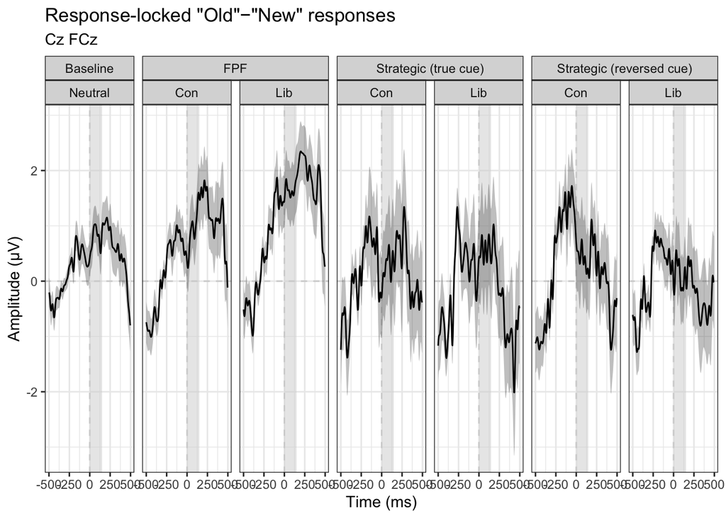

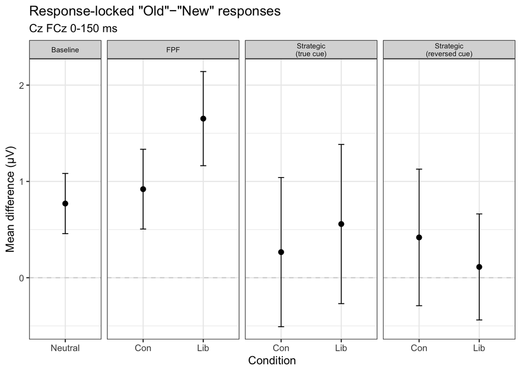

```r
# ERN
erpwave_in = erpwave_df_list$ERN
erpamp_in  = erpamp_df_list$ERN

# ==== plot diff ===============================================================
plot_custom_diff(erpwave_in, erpamp_in,
                 curr_erpname = "ERN",
                 curr_title = glue("\"Old\"{minus}\"New\" responses"),
                 contrast_var = "say_old", contrast_levels = c("Old","New"), save_fig=save_fig)
```

```r
# ==== model: task x cond x say_old, strategic/FPF only ========================
diffamp_model_df = collapse_levels(erpamp_in %>% filter(task!="Baseline"),
                                   contrast_var="say_old", type="amp") %>%
  filter(cell_ntrials >= min_n) %>%
  mutate(say_old = factor(say_old, levels=c("Old","New")),
         cond    = factor(cond, levels=c("Lib","Con")))

get_des(diffamp_model_df, vars = c("task","cond","say_old"))
```

| task | cond | say_old | mean | sd | nsub |
| --- | --- | --- | --- | --- | --- |
| FPF | Lib | Old | 2.4557377 | 4.846311 | 58 |
| FPF | Lib | New | 0.8036011 | 4.198790 | 58 |
| FPF | Con | Old | 2.3857764 | 4.444399 | 58 |
| FPF | Con | New | 1.4659143 | 4.036219 | 58 |
| Strategic (true cue) | Lib | Old | 3.7644180 | 4.638760 | 25 |
| Strategic (true cue) | Lib | New | 3.2066807 | 3.481576 | 25 |
| Strategic (true cue) | Con | Old | 2.8565515 | 3.661946 | 25 |
| Strategic (true cue) | Con | New | 2.5904337 | 3.948720 | 25 |
| Strategic (reversed cue) | Lib | Old | 1.9429501 | 3.589988 | 33 |
| Strategic (reversed cue) | Lib | New | 1.8307300 | 3.549170 | 33 |

[output cut: 2 more lines]

```r
model.lm = lmer(mean_amp ~ task0 * cond * say_old * cue + (1|sub) + (1|sub:taskcond) + (1|sub:say_old), data=diffamp_model_df)
model.emm   = emmeans(model.lm, ~ say_old * cond | task0 * cue, lmer.df = "satterthwaite")
model.pairs = pairs(model.emm)
model.emm; model.pairs
```

```
## task0 = FPF, cue = True:
##  say_old cond emmean    SE  df lower.CL upper.CL
##  Old     Lib   2.925 0.826 106    1.286     4.56
##  New     Lib   1.174 0.826 106   -0.465     2.81
##  Old     Con   3.102 0.826 106    1.464     4.74
##  New     Con   2.339 0.826 106    0.701     3.98
##
## task0 = Strategic, cue = True:
##  say_old cond emmean    SE  df lower.CL upper.CL
##  Old     Lib   3.764 0.826 106    2.126     5.40
##  New     Lib   3.207 0.826 106    1.568     4.85
##  Old     Con   2.857 0.826 106    1.218     4.50
##  New     Con   2.590 0.826 106    0.952     4.23
##
## task0 = FPF, cue = Reversed:
##  say_old cond emmean    SE  df lower.CL upper.CL
##  Old     Lib   2.101 0.719 106    0.674     3.53
##  New     Lib   0.523 0.719 106   -0.903     1.95
##  Old     Con   1.843 0.719 106    0.417     3.27
##  New     Con   0.804 0.719 106   -0.622     2.23
##
## task0 = Strategic, cue = Reversed:
##  say_old cond emmean    SE  df lower.CL upper.CL
##  Old     Lib   1.943 0.719 106    0.517     3.37
##  New     Lib   1.831 0.719 106    0.405     3.26
##  Old     Con   3.081 0.719 106    1.655     4.51
##  New     Con   2.663 0.719 106    1.236     4.09
##
## Degrees-of-freedom method: satterthwaite
## Confidence level used: 0.95
```

```
## task0 = FPF, cue = True:
##  contrast          estimate    SE  df t.ratio p.value
##  Old Lib - New Lib    1.751 0.729 138   2.402  0.0813
##  Old Lib - Old Con   -0.178 0.560 334  -0.318  0.9889
##  Old Lib - New Con    0.585 0.745 157   0.786  0.8609
##  New Lib - Old Con   -1.929 0.745 157  -2.590  0.0509
##  New Lib - New Con   -1.166 0.560 334  -2.082  0.1609
##  Old Con - New Con    0.763 0.729 138   1.047  0.7221
##
## task0 = Strategic, cue = True:
##  contrast          estimate    SE  df t.ratio p.value
##  Old Lib - New Lib    0.558 0.729 138   0.765  0.8699
##  Old Lib - Old Con    0.908 0.560 334   1.622  0.3678
##  Old Lib - New Con    1.174 0.745 157   1.576  0.3951
##  New Lib - Old Con    0.350 0.745 157   0.470  0.9655
##  New Lib - New Con    0.616 0.560 334   1.101  0.6893
##  Old Con - New Con    0.266 0.729 138   0.365  0.9833
##
## task0 = FPF, cue = Reversed:
##  contrast          estimate    SE  df t.ratio p.value
##  Old Lib - New Lib    1.577 0.634 138   2.486  0.0665
##  Old Lib - Old Con    0.258 0.487 334   0.529  0.9520
##  Old Lib - New Con    1.296 0.648 157   2.000  0.1924
##  New Lib - Old Con   -1.320 0.648 157  -2.036  0.1794
##  New Lib - New Con   -0.281 0.487 334  -0.576  0.9391
##  Old Con - New Con    1.039 0.634 138   1.637  0.3612
##
## task0 = Strategic, cue = Reversed:
##  contrast          estimate    SE  df t.ratio p.value
##  Old Lib - New Lib    0.112 0.634 138   0.177  0.9980
##  Old Lib - Old Con   -1.138 0.487 334  -2.336  0.0920
##  Old Lib - New Con   -0.720 0.648 157  -1.110  0.6838
##  New Lib - Old Con   -1.250 0.648 157  -1.929  0.2201
##  New Lib - New Con   -0.832 0.487 334  -1.707  0.3215
##  Old Con - New Con    0.419 0.634 138   0.660  0.9119
##
## Degrees-of-freedom method: satterthwaite
## P value adjustment: tukey method for comparing a family of 4 estimates
```

```r
# cond x response within each task, by cue group
eff_within   = contrast(emmeans(model.lm, ~ say_old * cond | task0 * cue,
                                lmer.df = "satterthwaite"), interaction = "pairwise")
# FPF vs strategic, by cue group
eff_taskcond = contrast(emmeans(model.lm, ~ say_old * cond * task0 | cue,
                                lmer.df = "satterthwaite"), interaction = "pairwise")
# true vs reversed, by task [FPF = consistency check]
eff_cue      = contrast(emmeans(model.lm, ~ say_old * cond * cue | task0,
                                lmer.df = "satterthwaite"), interaction = "pairwise")
# full sample, averaged over cue [report FPF row only]
eff_pooled   = contrast(emmeans(model.lm, ~ say_old * cond | task0,
                                lmer.df = "satterthwaite"), interaction = "pairwise")

summary(eff_within, by="cue", infer=c(T,T), adjust="holm")
```

|  | say_old_pairwise | cond_pairwise | task0 | cue | estimate | SE | df | lower.CL | upper.CL | t.ratio | p.value |
| --- | --- | --- | --- | --- | --- | --- | --- | --- | --- | --- | --- |
| 1 | Old - New | Lib - Con | FPF | True | 0.9878933 | 0.7614967 | 167.999 | -0.7343607 | 2.710147 | 1.2973047 | 0.3926101 |
| 2 | Old - New | Lib - Con | Strategic | True | 0.2916194 | 0.7614967 | 167.999 | -1.4306345 | 2.013873 | 0.3829556 | 0.7022368 |
| 3 | Old - New | Lib - Con | FPF | Reversed | 0.5386240 | 0.6627978 | 167.999 | -0.9604056 | 2.037654 | 0.8126521 | 0.8351353 |
| 4 | Old - New | Lib - Con | Strategic | Reversed | -0.3063902 | 0.6627978 | 167.999 | -1.8054199 | 1.192639 | -0.4622680 | 0.8351353 |

```r
summary(eff_taskcond,         infer=c(T,T))
```

|  | say_old_pairwise | cond_pairwise | task0_pairwise | cue | estimate | SE | df | lower.CL | upper.CL | t.ratio | p.value |
| --- | --- | --- | --- | --- | --- | --- | --- | --- | --- | --- | --- |
| 1 | Old - New | Lib - Con | FPF - Strategic | True | 0.6962739 | 1.0769190 | 167.999 | -1.429764 | 2.822311 | 0.6465425 | 0.5188104 |
| 2 | Old - New | Lib - Con | FPF - Strategic | Reversed | 0.8450143 | 0.9373377 | 167.999 | -1.005464 | 2.695492 | 0.9015047 | 0.3686107 |

```r
summary(eff_cue,              infer=c(T,T))
```

|  | say_old_pairwise | cond_pairwise | cue_pairwise | task0 | estimate | SE | df | lower.CL | upper.CL | t.ratio | p.value |
| --- | --- | --- | --- | --- | --- | --- | --- | --- | --- | --- | --- |
| 1 | Old - New | Lib - Con | True - Reversed | FPF | 0.4492692 | 1.009544 | 167.999 | -1.543757 | 2.442295 | 0.4450221 | 0.6568766 |
| 2 | Old - New | Lib - Con | True - Reversed | Strategic | 0.5980096 | 1.009544 | 167.999 | -1.395016 | 2.591036 | 0.5923564 | 0.5544084 |

```r
summary(eff_pooled,           infer=c(T,T))
```

|  | say_old_pairwise | cond_pairwise | task0 | estimate | SE | df | lower.CL | upper.CL | t.ratio | p.value |
| --- | --- | --- | --- | --- | --- | --- | --- | --- | --- | --- |
| 1 | Old - New | Lib - Con | FPF | 0.763258657 | 0.5047718 | 167.999 | -0.2332544 | 1.7597717 | 1.51208663 | 0.1323906 |
| 2 | Old - New | Lib - Con | Strategic | -0.007385411 | 0.5047718 | 167.999 | -1.0038984 | 0.9891276 | -0.01463119 | 0.9883438 |

```r
get_eff(model=model.lm, model_contrast = eff_within,   type="within")
```

```
## task0 = FPF, cue = True:
##  contrast              effect.size    SE  df lower.CL upper.CL
##  (Old - New Lib - Con)      0.2391 0.184 168   -0.125    0.603
##
## task0 = Strategic, cue = True:
##  contrast              effect.size    SE  df lower.CL upper.CL
##  (Old - New Lib - Con)      0.0706 0.184 168   -0.293    0.434
##
## task0 = FPF, cue = Reversed:
##  contrast              effect.size    SE  df lower.CL upper.CL
##  (Old - New Lib - Con)      0.1303 0.160 168   -0.186    0.447
##
## task0 = Strategic, cue = Reversed:
##  contrast              effect.size    SE  df lower.CL upper.CL
##  (Old - New Lib - Con)     -0.0741 0.160 168   -0.391    0.243
##
## sigma used for effect sizes: 4.132
## Degrees-of-freedom method: inherited from satterthwaite when re-gridding
## Confidence level used: 0.95
```

```r
get_eff(model=model.lm, model_contrast = eff_taskcond, type="within")
```

```
## cue = True:
##  contrast                              effect.size    SE  df lower.CL upper.CL
##  (Old - New Lib - Con FPF - Strategic)       0.168 0.261 168   -0.346    0.683
##
## cue = Reversed:
##  contrast                              effect.size    SE  df lower.CL upper.CL
##  (Old - New Lib - Con FPF - Strategic)       0.204 0.227 168   -0.244    0.652
##
## sigma used for effect sizes: 4.132
## Degrees-of-freedom method: inherited from satterthwaite when re-gridding
## Confidence level used: 0.95
```

```r
get_eff(model=model.lm, model_contrast = eff_cue,      type="within")
```

```
## task0 = FPF:
##  contrast                              effect.size    SE  df lower.CL upper.CL
##  (Old - New Lib - Con True - Reversed)       0.109 0.244 168   -0.374    0.591
##
## task0 = Strategic:
##  contrast                              effect.size    SE  df lower.CL upper.CL
##  (Old - New Lib - Con True - Reversed)       0.145 0.244 168   -0.338    0.627
##
## sigma used for effect sizes: 4.132
## Degrees-of-freedom method: inherited from satterthwaite when re-gridding
## Confidence level used: 0.95
```

```r
get_eff(model=model.lm, model_contrast = eff_pooled,   type="within")
```

```
## task0 = FPF:
##  contrast              effect.size    SE  df lower.CL upper.CL
##  (Old - New Lib - Con)     0.18470 0.122 168  -0.0568    0.426
##
## task0 = Strategic:
##  contrast              effect.size    SE  df lower.CL upper.CL
##  (Old - New Lib - Con)    -0.00179 0.122 168  -0.2429    0.239
##
## Results are averaged over the levels of: cue
## sigma used for effect sizes: 4.132
## Degrees-of-freedom method: inherited from satterthwaite when re-gridding
## Confidence level used: 0.95
```

# ERP-behavior correlations

- diffamp for F2, S2
- FRN, FPF lib only, [FA FPF - hit] ~ [FPF lib c - baseline c???]
- FRN diff (same as ^) ~ [strategic cshift] (distinct mechanisms predicts no relationship)
- FN400, FPF only, [old-new effect lib-con diff] ~ [FPF cshift]

```r
cshift = read.csv("../../data_code_beh/subj_summary/cshift.csv") %>% rename(sub=subID)
sdt_base = read.csv("../../data_code_beh/subj_summary/sdt_baseline.csv") %>% rename(sub=subID)

c_fpf_base = cshift %>% filter(task=="FPF") %>%
  select(sub,task,cshift,Lib) %>% rename(c2 = Lib) %>%
  bind_rows(sdt_base %>% select(sub,task,c2)) %>%
  pivot_wider(names_from=task,values_from=c(c2,cshift)) %>% select(-cshift_Baseline) %>%
  rename(c2_FPF_lib = c2_FPF) %>%
  mutate(fpf_base_cdiff = c2_FPF_lib - c2_Baseline)  # difference in c during FPF lib compared to baseline

# FRN effects
fpf_lib_hitfa_FRN = erpamp_df_list$FRN  %>% filter(task=="FPF" & cond=="Lib") %>%
  filter((cond=="Lib" & resptype_6 %in% c("Hit","FA (FPF)"))) %>%
  filter(cell_ntrials >= min_n) %>%
  mutate(cond = case_when(cond=="Lib" ~ glue("Lib (FA FPF{minus}Hit)"),
                          .default = NA)) %>%
  prep_erp_diffamp(contrast_var = "resptype_6", contrast_levels=c("FA (FPF)","Hit"), avg=FALSE) %>%
  merge(c_fpf_base, by="sub")

cor.test(fpf_lib_hitfa_FRN$diff, fpf_lib_hitfa_FRN$fpf_base_cdiff)  # FRN effect ~ lib FPF cshift relative to baseline
```

```
##
##  Pearson's product-moment correlation
##
## data:  fpf_lib_hitfa_FRN$diff and fpf_lib_hitfa_FRN$fpf_base_cdiff
## t = -0.65772, df = 56, p-value = 0.5134
## alternative hypothesis: true correlation is not equal to 0
## 95 percent confidence interval:
##  -0.3382015  0.1746923
## sample estimates:
##         cor
## -0.08755407
```

```r
cor.test(fpf_lib_hitfa_FRN$diff, fpf_lib_hitfa_FRN$c2_FPF_lib)      # FRN effect ~ lib FPF c
```

```
##
##  Pearson's product-moment correlation
##
## data:  fpf_lib_hitfa_FRN$diff and fpf_lib_hitfa_FRN$c2_FPF_lib
## t = 0.7119, df = 56, p-value = 0.4795
## alternative hypothesis: true correlation is not equal to 0
## 95 percent confidence interval:
##  -0.1676938  0.3445710
## sample estimates:
##        cor
## 0.09470403
```

```r
cshift_strategic_FRN = cshift %>% filter(task0=="Strategic") %>%
  rename(strategic_con = Con,
         strategic_lib = Lib,
         strategic_cshift = cshift) %>%
  select(sub, strategic_con, strategic_lib, strategic_cshift) %>%
  merge(fpf_lib_hitfa_FRN, by="sub")

# FRN effect ~ strategic cshift, by cue group [sanity check, should have NO relationship]
cor.test(~ diff+strategic_cshift, data = cshift_strategic_FRN %>% filter(cue=="True"))
```

```
##
##  Pearson's product-moment correlation
##
## data:  diff and strategic_cshift
## t = 0.84921, df = 23, p-value = 0.4045
## alternative hypothesis: true correlation is not equal to 0
## 95 percent confidence interval:
##  -0.2371057  0.5327852
## sample estimates:
##       cor
## 0.1743607
```

```r
cor.test(~ diff+strategic_cshift, data = cshift_strategic_FRN %>% filter(cue=="Reversed"))
```

```
##
##  Pearson's product-moment correlation
##
## data:  diff and strategic_cshift
## t = 0.48902, df = 31, p-value = 0.6283
## alternative hypothesis: true correlation is not equal to 0
## 95 percent confidence interval:
##  -0.2637364  0.4182406
## sample estimates:
##        cor
## 0.08749463
```

```r
# FN400 old-new effects
fpf_oldnew_FN400 = collapse_levels(erpamp_df_list$FN400 %>% filter(task == "FPF"),
                                   contrast_var="is_old", type="amp") %>%
  filter(cell_ntrials >= min_n) %>%
  select(sub, cond, is_old, mean_amp) %>%
  pivot_wider(names_from = c(cond, is_old), values_from = mean_amp) %>%
  mutate(lib_oldnew = Lib_Old - Lib_New,
         con_oldnew = Con_Old - Con_New,
         oldnew_libcon = lib_oldnew - con_oldnew) %>%   # FN400 diff in diff: is old/new effect larger in lib or con
  filter(!is.na(oldnew_libcon)) %>%
  merge(cshift %>% filter(task=="FPF"), by="sub") %>%
  rename(FPF_con = Con,
         FPF_lib = Lib,
         FPF_cshift = cshift)

cor.test(fpf_oldnew_FN400$oldnew_libcon, fpf_oldnew_FN400$FPF_cshift)  # lib-con diff in old-new diff ~ FPF cshift
```

```
##
##  Pearson's product-moment correlation
##
## data:  fpf_oldnew_FN400$oldnew_libcon and fpf_oldnew_FN400$FPF_cshift
## t = 0.93284, df = 56, p-value = 0.3549
## alternative hypothesis: true correlation is not equal to 0
## 95 percent confidence interval:
##  -0.1390398  0.3701671
## sample estimates:
##       cor
## 0.1236984
```

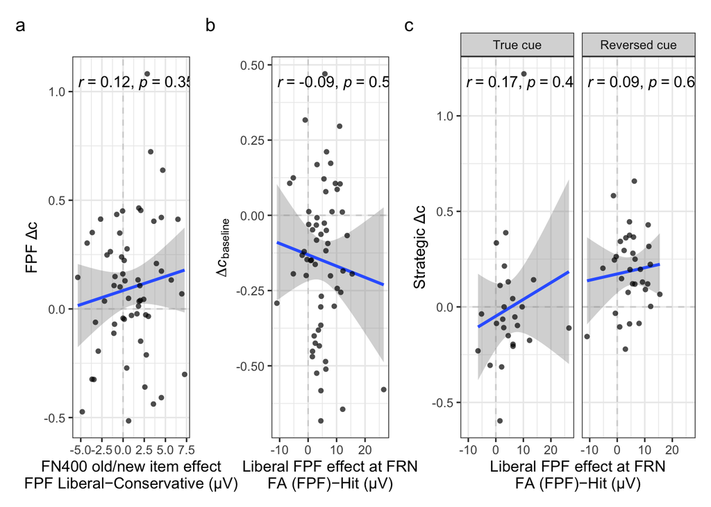

```r
library(ggpmisc)

#fpf_oldnew_FN400
#cshift_strategic_FRN

p1 = ggplot(fpf_oldnew_FN400, aes(x=oldnew_libcon,y=FPF_cshift)) +
  geom_hline(yintercept = 0, linetype = "dashed", color = "lightgray") +
  geom_vline(xintercept = 0, linetype = "dashed", color = "lightgray") +
  geom_smooth(method='lm', se=TRUE) +
  geom_point(alpha = 0.7,shape=16) +
  ggpmisc::stat_correlation(mapping = use_label(c("R", "P", "n")), small.r=TRUE, small.p=TRUE) +
  labs(x = glue("FN400 old/new item effect\nFPF Liberal{minus}Conservative (µV)"), y=glue("FPF {Delta}c")) +
  theme_bw()

p2 = ggplot(cshift_strategic_FRN, aes(x=diff,y=fpf_base_cdiff)) +
  geom_hline(yintercept = 0, linetype = "dashed", color = "lightgray") +
  geom_vline(xintercept = 0, linetype = "dashed", color = "lightgray") +
  geom_smooth(method='lm', se=TRUE) +
  geom_point(alpha = 0.7,shape=16) +
  ggpmisc::stat_correlation(mapping = use_label(c("R", "P", "n")), small.r=TRUE, small.p=TRUE) +
  labs(x = glue("Liberal FPF effect at FRN\nFA (FPF){minus}Hit (µV)"), y=expression(Delta*italic(c)[baseline])) +
  theme_bw()

p3 = ggplot(cshift_strategic_FRN, aes(x=diff,y=strategic_cshift)) +
  facet_grid(cols=vars(cue), labeller=as_labeller(c(True="True cue", Reversed="Reversed cue"))) +
  geom_hline(yintercept = 0, linetype = "dashed", color = "lightgray") +
  geom_vline(xintercept = 0, linetype = "dashed", color = "lightgray") +
  geom_smooth(method='lm', se=TRUE) +
  geom_point(alpha = 0.7,shape=16) +
  ggpmisc::stat_correlation(mapping = use_label(c("R", "P", "n")), small.r=TRUE, small.p=TRUE) +
  labs(x = glue("Liberal FPF effect at FRN\nFA (FPF){minus}Hit (µV)"), y=glue("Strategic {Delta}c")) +
  theme_bw()

(p1|p2|p3) + plot_layout(widths=c(1,1,2)) + plot_annotation(tag_levels = "a")  # patchwork
```

```r
if (isTRUE(save_fig)) {
  ggsave(".././ggsave/behavior_erp_corr.pdf", width=16,height=4, device=cairo_pdf)
}
```